# DATA MINING: FIFA 19

### Studente: Bugo

## SETUP

```python
# Python ≥3.5 is required
import sys
assert sys.version_info >= (3, 5)

# Scikit-Learn ≥0.20 is required
import sklearn
assert sklearn.__version__ >= "0.20"

# Common imports
import numpy as np
import os

#imports pandas
import pandas as ps
from IPython.display import Image
import os
#import warnings and Repress Warnings
import warnings
warnings.filterwarnings("ignore", message="numpy.dtype size changed")
warnings.filterwarnings("ignore", message="numpy.ufunc size changed")
warnings.filterwarnings("ignore", message="numpy.ndarray size changed")
warnings.filterwarnings('ignore')

# to make this notebook's output stable across runs
np.random.seed(42)

# To plot pretty figures
%matplotlib inline
import matplotlib as mpl
import matplotlib.pyplot as plt
import seaborn as sns
sns.set(style="whitegrid") #White Grid
mpl.rc('axes', labelsize=14)
mpl.rc('xtick', labelsize=12)
mpl.rc('ytick', labelsize=12)

# Where to save the figures
PROJECT_ROOT_DIR = "."
CHAPTER_ID= "ProgettoFifa19"
IMAGES_PATH = os.path.join(PROJECT_ROOT_DIR, "images")
os.makedirs(IMAGES_PATH, exist_ok=True)

def save_fig(fig_id, tight_layout=True, fig_extension="png", resolution=400):
    path = os.path.join(IMAGES_PATH, fig_id + "." + fig_extension)
    print("Saving figure", fig_id)
    if tight_layout:
        plt.tight_layout()
    plt.savefig(path, format=fig_extension, dpi=resolution)

def save_figure(figure, fig_id, tight_layout=False, fig_extension="png", resolution=400):
    path = os.path.join(IMAGES_PATH, fig_id + "." + fig_extension)
    print("Saving figure", fig_id)
    if tight_layout:
        plt.tight_layout()
    figure.savefig(path, format=fig_extension, dpi=resolution)

# Ignore useless warnings (see SciPy issue #5998)
import warnings
warnings.filterwarnings(action="ignore", message="^internal gelsd")
import warnings
warnings.filterwarnings('ignore')

# Hrule--> "====="
hrule = lambda x : "="*x
Hrule = lambda x,y: "="*(x//2)+y+"="*(x//2)
```

## MOTIVAZIONI DELLO STUDIO

FIFA, anche chiamata FIFA Soccer, è una serie di videogiochi di calcio sviluppata e pubblicata annualmente da Electronic Arts. La presenza delle licenze ne ha fatto uno dei videogiochi calcistici più venduti al mondo, a novembre 2010 l'editore ha dichiarato di aver superato le 100 milioni di copie vendute.

[figure not shown]

```python
Image(filename=os.path.join(IMAGES_PATH, 'copertina.jpg'), width=800)
```

Nel gioco sono disponibili diverse modalità di gioco, dalla semplice partita amichevole, ai tornei, al gioco online tramite Fifa Ultimate Team in cui è possibile comprare card di giocatori per creare la propria squadra, e la carriera da allenatore o giocatore. Proprio nella carriera allenatore, nella vesti del direttore della squadra, si ha la possibilità di giocare partite e di gestire anche l'aspetto economico della società, vendendo e comprando i giocatori. Ogni giocatore ha un overall calcolato sulla base del valori assunti dalle particolari voci quali crossing, finishing, balance, ecc., oltre che dai valori legati alle singole posizioni di gioco (LS, ST, RS, ecc.). In particolare, ogni caratteristica specifica di un giocatore ha un valore nel complesso differente rispetto alle altre. Ad esempio, l'overall di un difensore centrale verrà calcolato sulla base dei singoli valori legato all'aspetto difensivo, quale marcatura, colpi di testa, forza fisica, ecc., mentre per un attaccante verranno prese in considerazioni altre varaibili. L'algoritmo in FIFA, quindi, calcola l'overall assegnando un peso ad ogni voce, come mostrato dalla seguente figura relativa a FIFA 17.

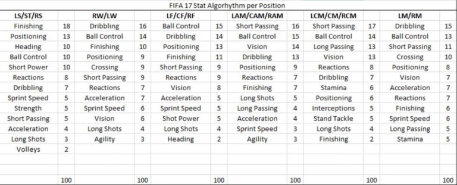

```python
Image(filename=os.path.join(IMAGES_PATH, 'tabellaValori.jpg'), width=800)
```

Mentre, quindi, l'overall viene calcolato in maniera statica sulla base dei pesi e dei valori delle singole statistiche, il valore di mercato dipende da tante variabili. L'obiettivo del seguente studio sarà, quindi, dopo aver studiato il dataset e individuate le variabili che concorrono maggiormente alla determinazione del campo Value, proprio quello di **predire il valore di mercato** di un giocatore attraverso tecniche di regressione lineare multipla.

## PRE PROCESSING

In questo primo passo verranno caricati i dati e verranno condotte delle prime analisi strutturali del dataset che porteranno all'individuazione di alcune trasformazioni necessarie per il proseguio delle analisi.

```python
ds = ps.read_csv("data.csv")
ps.set_option('display.max_columns', 89)
ds.head()
```

|  | Unnamed: 0 | ID | Name | Age | Photo | Nationality | Flag | Overall | Potential | Club | Club Logo | Value | Wage | Special | Preferred Foot | International Reputation | Weak Foot | Skill Moves | Work Rate | Body Type | Real Face | Position | Jersey Number | Joined | Loaned From | Contract Valid Until | Height | Weight | LS | … |
| --- | --- | --- | --- | --- | --- | --- | --- | --- | --- | --- | --- | --- | --- | --- | --- | --- | --- | --- | --- | --- | --- | --- | --- | --- | --- | --- | --- | --- | --- | --- |
| 0 | 0 | 158023 | L. Messi | 31 | https://cdn.sofifa.org/players/4/19/158023.png | Argentina | https://cdn.sofifa.org/flags/52.png | 94 | 94 | FC Barcelona | https://cdn.sofifa.org/teams/2/light/241.png | €110.5M | €565K | 2202 | Left | 5.0 | 4.0 | 4.0 | Medium/ Medium | Messi | Yes | RF | 10.0 | Jul 1, 2004 | NaN | 2021 | 5'7 | 159lbs | 88+2 | … |
| 1 | 1 | 20801 | Cristiano Ronaldo | 33 | https://cdn.sofifa.org/players/4/19/20801.png | Portugal | https://cdn.sofifa.org/flags/38.png | 94 | 94 | Juventus | https://cdn.sofifa.org/teams/2/light/45.png | €77M | €405K | 2228 | Right | 5.0 | 4.0 | 5.0 | High/ Low | C. Ronaldo | Yes | ST | 7.0 | Jul 10, 2018 | NaN | 2022 | 6'2 | 183lbs | 91+3 | … |
| 2 | 2 | 190871 | Neymar Jr | 26 | https://cdn.sofifa.org/players/4/19/190871.png | Brazil | https://cdn.sofifa.org/flags/54.png | 92 | 93 | Paris Saint-Germain | https://cdn.sofifa.org/teams/2/light/73.png | €118.5M | €290K | 2143 | Right | 5.0 | 5.0 | 5.0 | High/ Medium | Neymar | Yes | LW | 10.0 | Aug 3, 2017 | NaN | 2022 | 5'9 | 150lbs | 84+3 | … |
| 3 | 3 | 193080 | De Gea | 27 | https://cdn.sofifa.org/players/4/19/193080.png | Spain | https://cdn.sofifa.org/flags/45.png | 91 | 93 | Manchester United | https://cdn.sofifa.org/teams/2/light/11.png | €72M | €260K | 1471 | Right | 4.0 | 3.0 | 1.0 | Medium/ Medium | Lean | Yes | GK | 1.0 | Jul 1, 2011 | NaN | 2020 | 6'4 | 168lbs | NaN | … |
| 4 | 4 | 192985 | K. De Bruyne | 27 | https://cdn.sofifa.org/players/4/19/192985.png | Belgium | https://cdn.sofifa.org/flags/7.png | 91 | 92 | Manchester City | https://cdn.sofifa.org/teams/2/light/10.png | €102M | €355K | 2281 | Right | 4.0 | 5.0 | 4.0 | High/ High | Normal | Yes | RCM | 7.0 | Aug 30, 2015 | NaN | 2023 | 5'11 | 154lbs | 82+3 | … |

Si mostra, tramite il comando info(), le informazioni sul dataset, in particolare le righe (18207), le colonne (89) e il tipo di ogni colonna.

```python
ds.info()
```

```
<class 'pandas.core.frame.DataFrame'>
RangeIndex: 18207 entries, 0 to 18206
Data columns (total 89 columns):
Unnamed: 0                  18207 non-null int64
ID                          18207 non-null int64
Name                        18207 non-null object
Age                         18207 non-null int64
Photo                       18207 non-null object
Nationality                 18207 non-null object
Flag                        18207 non-null object
Overall                     18207 non-null int64
Potential                   18207 non-null int64
Club                        17966 non-null object
Club Logo                   18207 non-null object
Value                       18207 non-null object
Wage                        18207 non-null object
Special                     18207 non-null int64
Preferred Foot              18159 non-null object
International Reputation    18159 non-null float64
Weak Foot                   18159 non-null float64
Skill Moves                 18159 non-null float64
Work Rate                   18159 non-null object
Body Type                   18159 non-null object
Real Face                   18159 non-null object
Position                    18147 non-null object
Jersey Number               18147 non-null float64
Joined                      16654 non-null object
Loaned From                 1264 non-null object
Contract Valid Until        17918 non-null object
Height                      18159 non-null object
Weight                      18159 non-null object
LS                          16122 non-null object
ST                          16122 non-null object
RS                          16122 non-null object
LW                          16122 non-null object
LF                          16122 non-null object
CF                          16122 non-null object
RF                          16122 non-null object
RW                          16122 non-null object
LAM                         16122 non-null object
```

[output cut: 39 more lines]

```
Positioning                 18159 non-null float64
Vision                      18159 non-null float64
Penalties                   18159 non-null float64
Composure                   18159 non-null float64
Marking                     18159 non-null float64
StandingTackle              18159 non-null float64
SlidingTackle               18159 non-null float64
GKDiving                    18159 non-null float64
GKHandling                  18159 non-null float64
GKKicking                   18159 non-null float64
GKPositioning               18159 non-null float64
GKReflexes                  18159 non-null float64
Release Clause              16643 non-null object
dtypes: float64(38), int64(6), object(45)
memory usage: 12.4+ MB
```

Come si può osservare, il dataset presenta un elevato numero di colonne relative ai vari valori necessari per descrivere un giocatore e per determinare quindi il suo overall. In particolare, 38 colonne sono di tipo float (quelle relative ai punteggi delle singole statistiche), 6 sono di tipo intero (unnamed, id, age, potential, overall, special) e 45 di tipo object.

Inoltre, si osserva come sui 18207 record alcuni abbiano alcune colonne con valori nulli (NaN). In particolare, dalla rappresentazione tabellare precedente si nota che i portieri (GoalKeeper) non hanno specificati i valori relativi alle varie posizioni, il cui significato è di seguito riportato:

- **LS**, Left Striker
- **ST**, Striker
- **RS**, Right Striker
- **LW**, Left Wing
- **LF**, Left Forward
- **CF**, Center Forward
- **RF**, Right Forward
- **RW**, Right Wing
- **LAM**, Left Attacking Midfielder
- **CAM**, Center Attacking Midfielder
- **RAM**, Right Attacking Midfielder
- **LM**, Left Midfielder
- **LCM**, Left Center Midfielder
- **CM**, Center Midfielder
- **RCM**, Right Center Midfielder
- **RM**, Right Midfielder
- **LWB**, Left Wing Back
- **LDM**, Left Defensive Midfielder
- **CDM**, Center Defensive Midfielder
- **RDM**, Right Defensive Midfielder
- **RWB**, Right Wing Back
- **LB**, Left Back
- **LCB**, Left Center Midfielder
- **CB**, Center Back
- **RCB**, Right Center Back
- **RB**, Righ Back

Tutti i giocatori, invece, hanno specificato i valori relativi al ruolo di portiere (GKDiving, GKHandling, ecc.).

Innanzitutto si eliminano, tramite il comando drop, alcune colonne che non sono significative ai fini dell'analisi, in particolare quelle contenenti informazioni per identificare i giocatori (Unnamed, Name, ID), degli url ad immagini (Photo, Flag, Club Logo), altre relative all'aspetto fisico dei giocatori (Real Face, valore booleano che indica che il giocatore è rappresentato da una sua foto e non da una ricostruzione digitale).

```python
ds.drop(columns=['Unnamed: 0', 'Name', 'ID', 'Photo', 'Flag', 'Club Logo', 'Real Face'], inplace = True)
```

Le colonne rimanenti sono quelle indicate dal comando columns.

```python
ds.columns
```

```
Index(['Age', 'Nationality', 'Overall', 'Potential', 'Club', 'Value', 'Wage',
       'Special', 'Preferred Foot', 'International Reputation', 'Weak Foot',
       'Skill Moves', 'Work Rate', 'Body Type', 'Position', 'Jersey Number',
       'Joined', 'Loaned From', 'Contract Valid Until', 'Height', 'Weight',
       'LS', 'ST', 'RS', 'LW', 'LF', 'CF', 'RF', 'RW', 'LAM', 'CAM', 'RAM',
       'LM', 'LCM', 'CM', 'RCM', 'RM', 'LWB', 'LDM', 'CDM', 'RDM', 'RWB', 'LB',
       'LCB', 'CB', 'RCB', 'RB', 'Crossing', 'Finishing', 'HeadingAccuracy',
       'ShortPassing', 'Volleys', 'Dribbling', 'Curve', 'FKAccuracy',
       'LongPassing', 'BallControl', 'Acceleration', 'SprintSpeed', 'Agility',
       'Reactions', 'Balance', 'ShotPower', 'Jumping', 'Stamina', 'Strength',
       'LongShots', 'Aggression', 'Interceptions', 'Positioning', 'Vision',
       'Penalties', 'Composure', 'Marking', 'StandingTackle', 'SlidingTackle',
       'GKDiving', 'GKHandling', 'GKKicking', 'GKPositioning', 'GKReflexes',
       'Release Clause'],
      dtype='object')
```

A questo punto verranno eseguite delle prime trasformazioni del dataset, in particolare relative alla gestione dei valori nulli e alla conversione dei formati, che si rendono necessari al fine di visualizzare correttamente i dati. Infatti, seppur il processo di *data cleaning* serva come passo preliminare agli algoritmi di machine learning, in questo caso non sarebbe stato possibile rappresentare alcuni attributi necessari a comprendere bene il dataset e quali variabili considerare, come ad esempio l'attributo Value e come questo sia legato agli altri attributi. Ulteriori trasformazioni verranno effettuate più avanti attraverso la libreria sklearn.

Innanzitutto si eliminano i duplicati.

```python
ds.drop_duplicates(keep='first', inplace=True)
print(ds.shape)
```

```
(18207, 82)
```

Per ridurre ulteriormente la quantità di dati si vede se ci sono colonne che presentano pochi valori e che possono essere, pertanto, trascurate. In particolare, la soglia è stata settata alla metà dei record presenti del dataset. Si vede, quindi, che per quanto riguarda la colonna Loaned From, indicante la squadra da cui il giocatore proviene, su 18207 tuple ben 16943 (93%) hanno valori NaN, pertanto si procede all'eliminazione della suddetta colonna.

```python
ds.isnull().sum()[ds.isnull().sum() >= ds.shape[0]/2]
```

```
Loaned From    16943
dtype: int64
```

```python
ds.drop(labels='Loaned From', axis=1, inplace=True)
```

Si analizzano ulteriori valori NaN.

```python
ds.isnull().sum()
```

```
Age                            0
Nationality                    0
Overall                        0
Potential                      0
Club                         241
Value                          0
Wage                           0
Special                        0
Preferred Foot                48
International Reputation      48
Weak Foot                     48
Skill Moves                   48
Work Rate                     48
Body Type                     48
Position                      60
Jersey Number                 60
Joined                      1553
Contract Valid Until         289
Height                        48
Weight                        48
LS                          2085
ST                          2085
RS                          2085
LW                          2085
LF                          2085
CF                          2085
RF                          2085
RW                          2085
LAM                         2085
CAM                         2085
                            ...
Dribbling                     48
Curve                         48
FKAccuracy                    48
LongPassing                   48
BallControl                   48
Acceleration                  48
SprintSpeed                   48
Agility                       48
Reactions                     48
Balance                       48
ShotPower                     48
Jumping                       48
Stamina                       48
Strength                      48
LongShots                     48
Aggression                    48
Interceptions                 48
Positioning                   48
Vision                        48
Penalties                     48
Composure                     48
Marking                       48
StandingTackle                48
SlidingTackle                 48
GKDiving                      48
GKHandling                    48
GKKicking                     48
GKPositioning                 48
GKReflexes                    48
Release Clause              1564
Length: 81, dtype: int64
```

```python
ds.drop(index=ds[ds['Preferred Foot'].isna()].index, inplace=True)
```

```python
ds.drop(index=ds[ds['Position'].isna()].index, inplace=True)
```

```python
ds.drop(index=ds[ds['Overall'].isna()].index, inplace=True)
```

A questo punto si definiscono una serie di trasformazioni per riempire altri valori nulli tramite l'oggetto Imputer della libreria sklearn. In particolare, SimpleImputer permette di usare quattro diverse strategie per il rimpiazzamento dei valori NaN: *median*, *mean*, *most_frequent*, e *constant*. Si fanno le seguenti assunzioni per i campi Joined, Contract Valid Until, Release Clause, Club, Weight e Height:

```python
len(ds[ds['Position'] == 'GK'])
```

```
2025
```

```python
from sklearn.impute import SimpleImputer

imputerAge = SimpleImputer(strategy='median', copy=True, missing_values=np.nan, verbose=0)
imputerNationality = SimpleImputer(strategy="most_frequent", copy=True, missing_values=np.nan, verbose=0)
imputerOverall_Potential = SimpleImputer(strategy="mean", copy=True, missing_values=np.nan, verbose=0)
imputerClub = SimpleImputer(strategy='constant', fill_value="No Club", copy=True, missing_values=np.nan, verbose=0) # valori nulli club
imputer_from_value_to_jersey = SimpleImputer(strategy="most_frequent", copy=True, missing_values=np.nan, verbose=0)
imputer_contract = SimpleImputer(strategy="constant", fill_value = "2022",copy=True, missing_values=np.nan, verbose=0)
imputer_joined = SimpleImputer(strategy="constant", fill_value = "2019",copy=True, missing_values=np.nan, verbose=0)
imputer_height = SimpleImputer(strategy='constant', fill_value = "5'9",copy=True, missing_values=np.nan, verbose=0)
imputer_weight = SimpleImputer(strategy='constant', fill_value = "155lbs",copy=True, missing_values=np.nan, verbose=0)
imputerPositions = SimpleImputer(strategy='constant', fill_value="00+0", copy=True, missing_values=np.nan, verbose=0)
imputerValues = SimpleImputer(strategy='median', copy=True, missing_values=np.nan, verbose=0)
imputerClause = SimpleImputer(strategy='constant', fill_value="€0M", copy=True, missing_values=np.nan, verbose=0)
```

Si definiscono le Pipeline relative alle varie trasformazioni da effettuare, che, dopo essere state applicate ai rispettivi dati del dataset, verranno eseguite tramite un ColumnTransformer.

```python
from sklearn.compose import ColumnTransformer
from sklearn.pipeline import Pipeline

from_value_to_jersey = ['Value', 'Wage','Special', 'Preferred Foot', 'International Reputation', 'Weak Foot','Skill Moves', 'Work Rate', 'Body Type', 'Position', 'Jersey Number']
overall_potential = ['Overall', 'Potential']
positions = ['LS','ST','RS','LW','LF','CF','RF','RW','LAM','CAM','RAM','LM','LCM','CM','RCM','RM','LWB','LDM','CDM','RDM','RWB','LB','LCB', 'CB', 'RCB', 'RB']
values = ['Crossing', 'Finishing', 'HeadingAccuracy',
       'ShortPassing', 'Volleys', 'Dribbling', 'Curve', 'FKAccuracy',
       'LongPassing', 'BallControl', 'Acceleration', 'SprintSpeed', 'Agility',
       'Reactions', 'Balance', 'ShotPower', 'Jumping', 'Stamina', 'Strength',
       'LongShots', 'Aggression', 'Interceptions', 'Positioning', 'Vision',
       'Penalties', 'Composure', 'Marking', 'StandingTackle', 'SlidingTackle',
       'GKDiving', 'GKHandling', 'GKKicking', 'GKPositioning', 'GKReflexes']

pipe_1 = Pipeline([
        ('imputer',imputerAge)
    ])
pipe_1_res = pipe_1.fit_transform(ds[['Age']])


pipe_2 = Pipeline([
        ('imputer', imputerNationality)
    ])
pipe_2_res = pipe_2.fit_transform(ds[['Nationality']])


pipe_3 = Pipeline([
        ('imputer', imputerOverall_Potential)
    ])
pipe_3_res = pipe_3.fit_transform(ds[overall_potential])


pipe_4 = Pipeline([
        ('imputer', imputerClub)
    ])
pipe_4_res = pipe_4.fit_transform(ds[['Club']])


pipe_5 = Pipeline([('imputer', imputer_from_value_to_jersey)])
pipe_5_res = pipe_5.fit_transform(ds[from_value_to_jersey])

pipe_7 = Pipeline([
        ('imputer', imputer_joined)
    ])
pipe_7_res = pipe_7.fit_transform(ds[['Joined']])

pipe_6 = Pipeline([
        ('imputer', imputer_contract)
    ])
pipe_6_res = pipe_6.fit_transform(ds[['Contract Valid Until']])


pipe_8 = Pipeline([
        ('imputer', imputer_height)
    ])
pipe_8_res = pipe_8.fit_transform(ds[['Height']])

pipe_8_1 = Pipeline([
        ('imputer', imputer_weight)
    ])
pipe_8_1_res = pipe_8_1.fit_transform(ds[['Weight']])

pipe_9 = Pipeline([
        ('imputer', imputerPositions)
    ])
pipe_9_res = pipe_9.fit_transform(ds[positions])

pipe_10 = Pipeline([
        ('imputer', imputerValues)
    ])
pipe_10_res = pipe_10.fit_transform(ds[values])


pipe_11 = Pipeline([
        ('imputer', imputerClause)
    ])
pipe_11_res = pipe_11.fit_transform(ds[['Release Clause']])
```

```python
from sklearn.compose import ColumnTransformer

full_pipeline_imputer = ColumnTransformer([
       ("pipe_1", pipe_1, ['Age']),
        ("pipe_2", pipe_2, ['Nationality']),
        ("pipe_3", pipe_3, overall_potential),
        ("pipe_4", pipe_4, ['Club']),
        ("pipe_5", pipe_5, from_value_to_jersey),
        ("pipe_7", pipe_7, ['Joined']),
        ("pipe_6", pipe_6, ['Contract Valid Until']),
        ("pipe_8", pipe_8, ['Height']),
        ("pipe_8_1", pipe_8_1, ['Weight']),
        ("pipe_9", pipe_9, positions),
        ("pipe_10", pipe_10, values),
        ("pipe_11", pipe_11, ['Release Clause'])])

X = full_pipeline_imputer.fit_transform(ds)
```

Si mappa il dataset X trasformato con le colonne originali.

```python
ds = ps.DataFrame(X, columns=ds.columns)
```

```python
ds.head()
```

|  | Age | Nationality | Overall | Potential | Club | Value | Wage | Special | Preferred Foot | International Reputation | Weak Foot | Skill Moves | Work Rate | Body Type | Position | Jersey Number | Joined | Contract Valid Until | Height | Weight | LS | ST | RS | LW | LF | CF | RF | RW | LAM | … |
| --- | --- | --- | --- | --- | --- | --- | --- | --- | --- | --- | --- | --- | --- | --- | --- | --- | --- | --- | --- | --- | --- | --- | --- | --- | --- | --- | --- | --- | --- | --- |
| 0 | 31 | Argentina | 94 | 94 | FC Barcelona | €110.5M | €565K | 2202 | Left | 5 | 4 | 4 | Medium/ Medium | Messi | RF | 10 | Jul 1, 2004 | 2021 | 5'7 | 159lbs | 88+2 | 88+2 | 88+2 | 92+2 | 93+2 | 93+2 | 93+2 | 92+2 | 93+2 | … |
| 1 | 33 | Portugal | 94 | 94 | Juventus | €77M | €405K | 2228 | Right | 5 | 4 | 5 | High/ Low | C. Ronaldo | ST | 7 | Jul 10, 2018 | 2022 | 6'2 | 183lbs | 91+3 | 91+3 | 91+3 | 89+3 | 90+3 | 90+3 | 90+3 | 89+3 | 88+3 | … |
| 2 | 26 | Brazil | 92 | 93 | Paris Saint-Germain | €118.5M | €290K | 2143 | Right | 5 | 5 | 5 | High/ Medium | Neymar | LW | 10 | Aug 3, 2017 | 2022 | 5'9 | 150lbs | 84+3 | 84+3 | 84+3 | 89+3 | 89+3 | 89+3 | 89+3 | 89+3 | 89+3 | … |
| 3 | 27 | Spain | 91 | 93 | Manchester United | €72M | €260K | 1471 | Right | 4 | 3 | 1 | Medium/ Medium | Lean | GK | 1 | Jul 1, 2011 | 2020 | 6'4 | 168lbs | 00+0 | 00+0 | 00+0 | 00+0 | 00+0 | 00+0 | 00+0 | 00+0 | 00+0 | … |
| 4 | 27 | Belgium | 91 | 92 | Manchester City | €102M | €355K | 2281 | Right | 4 | 5 | 4 | High/ High | Normal | RCM | 7 | Aug 30, 2015 | 2023 | 5'11 | 154lbs | 82+3 | 82+3 | 82+3 | 87+3 | 87+3 | 87+3 | 87+3 | 87+3 | 88+3 | … |

A questo punto non restano campi con valori nulli.

```python
ds.isnull().sum()
```

```
Age                         0
Nationality                 0
Overall                     0
Potential                   0
Club                        0
Value                       0
Wage                        0
Special                     0
Preferred Foot              0
International Reputation    0
Weak Foot                   0
Skill Moves                 0
Work Rate                   0
Body Type                   0
Position                    0
Jersey Number               0
Joined                      0
Contract Valid Until        0
Height                      0
Weight                      0
LS                          0
ST                          0
RS                          0
LW                          0
LF                          0
CF                          0
RF                          0
RW                          0
LAM                         0
CAM                         0
                           ..
Dribbling                   0
Curve                       0
FKAccuracy                  0
LongPassing                 0
BallControl                 0
Acceleration                0
SprintSpeed                 0
Agility                     0
Reactions                   0
Balance                     0
ShotPower                   0
Jumping                     0
Stamina                     0
Strength                    0
LongShots                   0
Aggression                  0
Interceptions               0
Positioning                 0
Vision                      0
Penalties                   0
Composure                   0
Marking                     0
StandingTackle              0
SlidingTackle               0
GKDiving                    0
GKHandling                  0
GKKicking                   0
GKPositioning               0
GKReflexes                  0
Release Clause              0
Length: 81, dtype: int64
```

Il dataset a questo punto è stato ripulito dei valori mancanti. Si presentano le statistiche generali sul dataset così ottenuto tramite la funzione describe.

```python
ds.describe()
```

|  | Age | Nationality | Overall | Potential | Club | Value | Wage | Special | Preferred Foot | International Reputation | Weak Foot | Skill Moves | Work Rate | Body Type | Position | Jersey Number | Joined | Contract Valid Until | Height | Weight | LS | ST | RS | LW | LF | CF | RF | RW | LAM | … |
| --- | --- | --- | --- | --- | --- | --- | --- | --- | --- | --- | --- | --- | --- | --- | --- | --- | --- | --- | --- | --- | --- | --- | --- | --- | --- | --- | --- | --- | --- | --- |
| count | 18147.0 | 18147 | 18147.0 | 18147.0 | 18147 | 18147 | 18147 | 18147 | 18147 | 18147.0 | 18147.0 | 18147.0 | 18147 | 18147 | 18147 | 18147.0 | 18147 | 18147 | 18147 | 18147 | 18147 | 18147 | 18147 | 18147 | 18147 | 18147 | 18147 | 18147 | 18147 | … |
| unique | 29.0 | 164 | 48.0 | 47.0 | 652 | 217 | 144 | 1422 | 2 | 5.0 | 5.0 | 5.0 | 9 | 10 | 27 | 99.0 | 1737 | 36 | 21 | 57 | 94 | 94 | 94 | 106 | 103 | 103 | 103 | 106 | 102 | … |
| top | 21.0 | England | 66.0 | 70.0 | No Club | €1.1M | €1K | 1745 | Right | 1.0 | 3.0 | 2.0 | Medium/ Medium | Normal | ST | 8.0 | Jul 1, 2018 | 2019 | 6'0 | 165lbs | 00+0 | 00+0 | 00+0 | 00+0 | 00+0 | 00+0 | 00+0 | 00+0 | 00+0 | … |
| freq | 1420.0 | 1657 | 1162.0 | 1197.0 | 229 | 431 | 4873 | 47 | 13938 | 16520.0 | 11341.0 | 8556.0 | 9804 | 10588 | 2152 | 612.0 | 1538 | 4819 | 2880 | 1483 | 2025 | 2025 | 2025 | 2025 | 2025 | 2025 | 2025 | 2025 | 2025 | … |

Si definiscono a questo punto delle funzioni per la conversione degli attributi categorici in numerici. In particolare si defiscono delle funzioni per la conversione dei valori dei campi *positions*, che sono espressi da una stringa indicante la somma di due interi (overall + tasso di crescita), una funzione per la conversione del peso e dell'altezza, per la conversione dei campi Value, Release Clause e Wage, e per la conversione dei campi Joined e Contract Valid Until.

```python
def valueConvert(val):
    if type(val) == str:
        return int(val[0:2])+int(val[-1])
    else:
        return val
```

```python
def heightConvert(val):
    if (type(val) == str):
        a = val.split("'")
        return (int(a[0])*30.48+int(a[1])*2.54)
    else:
        return val
```

```python
def weightConvert(val):
    if (type(val) == str):
        a = int(val.split("lbs")[0])
        return a/2.205
    else:
        return val
```

```python
def currencyConvert(val):
    if val[-1] == 'M':
        return float(val[1:-1])
    elif val[-1] == 'K':
        return float(val[1:-1])*0.001
    else:
        return 0
```

```python
def contractValidityConvert(val):
    if (type(val) == str):
        a = val.split(",")
        if (len(a) == 1):
            return int(a[0])
        elif (len(a) == 2):
            return int(a[1])
    elif (type(val) == int):
        return val
```

Si applicano le funzioni appene definite.

```python
for c in positions:
    ds[c] = ds[c].apply(valueConvert)
```

```python
ds['Weight'] = ds['Weight'].apply(weightConvert)
```

```python
ds['Height'] = ds['Height'].apply(heightConvert)
```

```python
ds['Value'] = ds['Value'].apply(currencyConvert)
ds['Wage'] = ds['Wage'].apply(currencyConvert)
ds['Release Clause'] = ds['Release Clause'].apply(currencyConvert)
```

Nella trasformazione dei campi Contract Valid Until e Joined, dove appaiono anche delle date complete con giorno, mese e anno, si considera solo l'anno in questione.

```python
ds['Contract Valid Until'].unique()
```

```
array(['2021', '2022', '2020', '2023', '2019', '2024', 'Jun 30, 2019',
       '2025', '2026', 'Dec 31, 2018', '2018', 'May 31, 2020',
       'Jun 30, 2020', 'May 31, 2019', 'Dec 31, 2019', 'Jan 1, 2019',
       'Jun 1, 2019', 'Jan 4, 2019', 'Jan 31, 2019', 'Jan 7, 2019',
       'Jan 2, 2019', 'Jan 6, 2019', 'Oct 14, 2019', 'Jan 3, 2019',
       'May 4, 2019', 'Jan 12, 2019', 'Jan 25, 2019', 'Jan 18, 2019',
       'Dec 1, 2019', 'Nov 30, 2018', 'Feb 27, 2020', 'Jan 5, 2019',
       'Jan 15, 2019', 'Jan 30, 2019', 'Jan 11, 2019', 'Jan 20, 2019'],
      dtype=object)
```

```python
ds['Contract Valid Until'] = ds['Contract Valid Until'].apply(contractValidityConvert)
ds['Joined'] = ds['Joined'].apply(contractValidityConvert)
```

Infine, si trasformano, laddove possibile, i campi float in campi int.

```python
ds['Age'] = ds['Age'].astype(np.int64)
ds['Overall'] = ds['Overall'].astype(np.int64)
ds['Potential'] = ds['Potential'].astype(np.int64)
ds['Jersey Number'] = ds['Jersey Number'].astype(np.int64)
ds['International Reputation'] = ds['International Reputation'].astype(np.int64)
ds[values] = ds[values].astype(np.int64)
```

Il dataset modificato si presenta nel seguente modo:

```python
ds.head()
```

|  | Age | Nationality | Overall | Potential | Club | Value | Wage | Special | Preferred Foot | International Reputation | Weak Foot | Skill Moves | Work Rate | Body Type | Position | Jersey Number | Joined | Contract Valid Until | Height | Weight | LS | ST | RS | LW | LF | CF | RF | RW | LAM | … |
| --- | --- | --- | --- | --- | --- | --- | --- | --- | --- | --- | --- | --- | --- | --- | --- | --- | --- | --- | --- | --- | --- | --- | --- | --- | --- | --- | --- | --- | --- | --- |
| 0 | 31 | Argentina | 94 | 94 | FC Barcelona | 110.5 | 0.565 | 2202 | Left | 5 | 4 | 4 | Medium/ Medium | Messi | RF | 10 | 2004 | 2021 | 170.18 | 72.108844 | 90 | 90 | 90 | 94 | 95 | 95 | 95 | 94 | 95 | … |
| 1 | 33 | Portugal | 94 | 94 | Juventus | 77.0 | 0.405 | 2228 | Right | 5 | 4 | 5 | High/ Low | C. Ronaldo | ST | 7 | 2018 | 2022 | 187.96 | 82.993197 | 94 | 94 | 94 | 92 | 93 | 93 | 93 | 92 | 91 | … |
| 2 | 26 | Brazil | 92 | 93 | Paris Saint-Germain | 118.5 | 0.290 | 2143 | Right | 5 | 5 | 5 | High/ Medium | Neymar | LW | 10 | 2017 | 2022 | 175.26 | 68.027211 | 87 | 87 | 87 | 92 | 92 | 92 | 92 | 92 | 92 | … |
| 3 | 27 | Spain | 91 | 93 | Manchester United | 72.0 | 0.260 | 1471 | Right | 4 | 3 | 1 | Medium/ Medium | Lean | GK | 1 | 2011 | 2020 | 193.04 | 76.190476 | 0 | 0 | 0 | 0 | 0 | 0 | 0 | 0 | 0 | … |
| 4 | 27 | Belgium | 91 | 92 | Manchester City | 102.0 | 0.355 | 2281 | Right | 4 | 5 | 4 | High/ High | Normal | RCM | 7 | 2015 | 2023 | 180.34 | 69.841270 | 85 | 85 | 85 | 90 | 90 | 90 | 90 | 90 | 91 | … |

## VISUALIZATION

A questo punto, dopo aver applicato le dovute trasformazioni al dataset, si procede alla visualizzazione dei dati per individuare i fattori che influenzano il valore di mercato di un giocatore.

Si osserva per primo la distribuzione di alcuni attributi numerici (posizioni e valori di gioco esclusi) tramite degli istrogrammi.

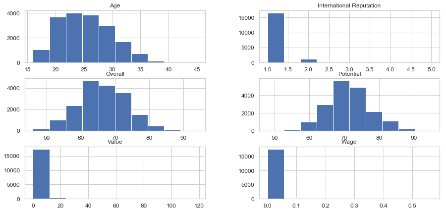

```python
# plot some graphs useful for visualizing the distribution of
# the values wrt to each individual feature
%matplotlib inline

ds1 = ds[['Age','Overall','Potential','Value','Wage','International Reputation', 'Weak Foot','Skill Moves']]

ds1.hist(figsize=(15,7))
# save_fig("attribute_histogram_plots")
plt.show()
```

Di seguito, invece, vengono mostrate le distribuzioni dei valori relative alla posizioni di gioco, indicate dalla lista *positions*

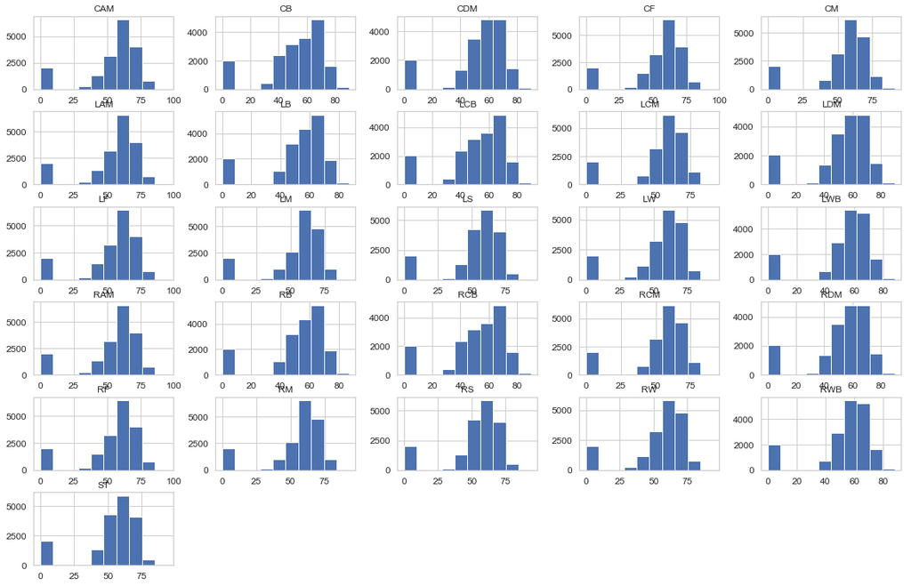

```python
# plot some graphs useful for visualizing the distribution of
# the values wrt to each individual feature
%matplotlib inline
ds1 = ds[positions]

ds1.hist(figsize=(20,13))
# save_fig("attribute_histogram_plots")
plt.show()
```

Le colonne 0 sono relative ai portieri.

Si mostra nel dettaglio la distribuzione degli overall dei giocatori. Si osserva una distribuzione normale con il picco che si assesta sui 65 circa, considerando probabilmentei tanti giocatori di serie minori.

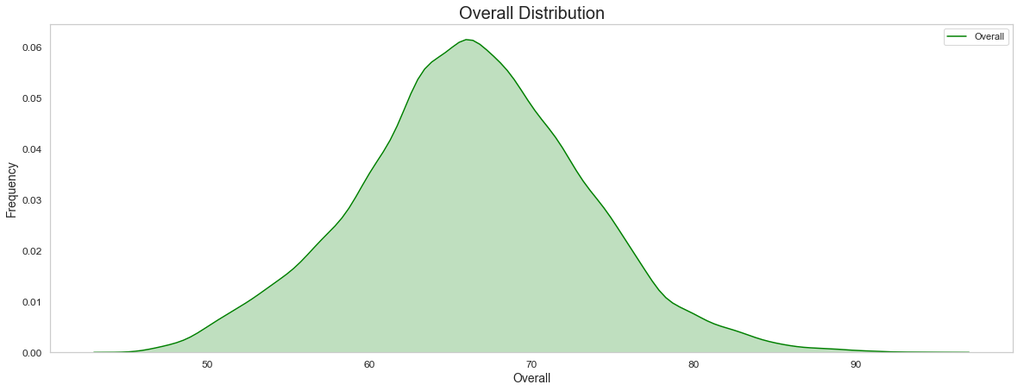

```python
plt.figure(figsize=(20,7))
p = sns.kdeplot(ds.Overall, shade=True,color='green')
plt.grid()
plt.ylabel('Frequency')
plt.xlabel('Overall')
plt.title("Overall Distribution", size=20)
plt.show()
# figure = p.get_figure()
# save_figure(figure,"Overall Distribution.png")
```

Per quanto riguarda l'attributo target Value, si ha la seguente distribuzione che mostra come, in accordo all'overall prima analizzato, i valori bassi sono più frequenti (tra 0 e 20 milioni). Qualche giocatore, invece, presenta un valore elevato (120).

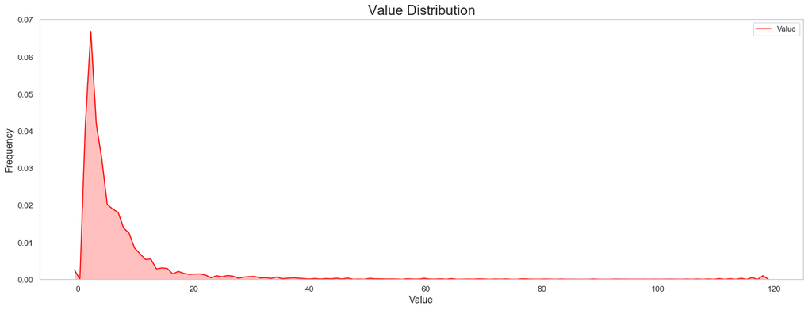

```python
plt.figure(figsize=(20,7))
p = sns.kdeplot(ds.Value, shade=True,color='red')
plt.grid()
plt.xlabel('Value')
plt.ylabel('Frequency')
plt.title("Value Distribution", size=20)
plt.show()
# figure = p.get_figure()
# save_figure(figure,"Value Distribution.png")
```

Come è normale aspettarsi, giocatori con overall elevati hanno un valore elevato, come mostrato dal seguente grafico in cui il valore medio cresce quasi in maniera direttamente proporzionata al talento del giocatore.

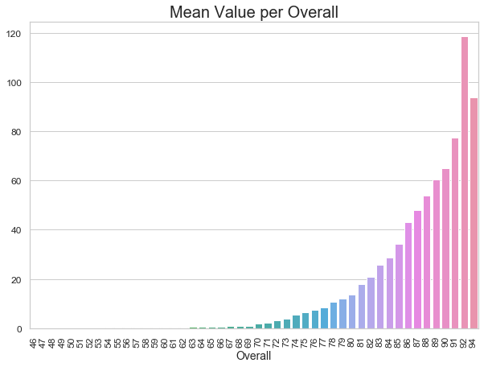

```python
plt.figure(figsize=(10,7))
mean_value_per_overall = ds.groupby('Overall')['Value'].mean()
p = sns.barplot(x = mean_value_per_overall.index, y =mean_value_per_overall.values)
p = plt.xticks(rotation=90)
plt.title("Mean Value per Overall", size=20)
# save_fig("Mean Value per Overall.png")
```

Una volta osservato che il valore di mercato dipende fortemente dall'overall, si cerca di capire come questo evolve in relazione all'età, considerando di pari passo anche il potenziale.

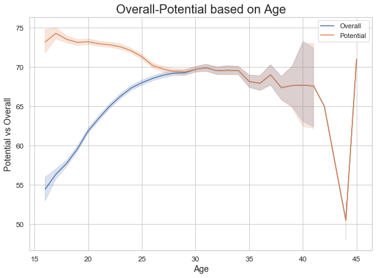

```python
plt.figure(figsize=(10,7))
p = sns.lineplot(x = 'Age', y = 'Overall', data = ds, label = 'Overall')
p = sns.lineplot(x = 'Age', y = 'Potential', data = ds, label = 'Potential')
p = plt.ylabel('Potential vs Overall')
plt.title("Overall-Potential based on Age", size=20)
# figure = p.get_figure()
# save_figure(figure,"Overall-Potential based on Age.png")
```

Dal grafico presentato si nota come a partire dai 16 anni i giocatori hanno basso overall e alto potenziale (55-75 circa), con le due curve che si avvicinano sempre più fino a che, dopo circa i 27 anni, i giocatori non crescono più a livello di overall. C'è quindi una qualche correlazione tra valore di mercato e potenziale dal giocatore, come mostrato dal seguente grafico.

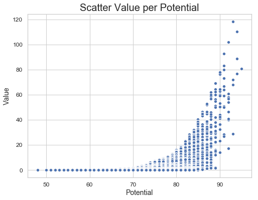

```python
plt.figure(figsize=(8,6))
p = sns.scatterplot(x = 'Potential', y = 'Value', data = ds)
plt.title("Scatter Value per Potential", size=20)
# figure = p.get_figure()
# save_figure(figure,"Scatter Value per Potential.png")
```

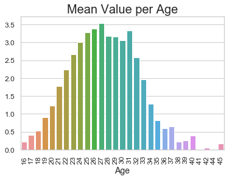

```python
mean_value_per_age = ds.groupby('Age')['Value'].mean()
p = sns.barplot(x = mean_value_per_age.index, y = mean_value_per_age.values)
p = plt.xticks(rotation=90)
plt.title("Mean Value per Age", size=20)
# save_fig("Mean Value per Age.png")
```

I giocatori hanno un valore maggiore trai 23 e i 30 anni (anni fiorenti della vita calcistica di un giocatore), dove poi inizia una fase calante del valore fino al ritiro.

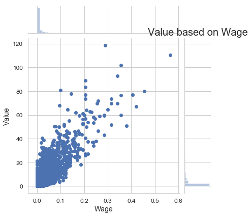

```python
plt.figure(figsize=(20,10))
p = sns.jointplot(x = 'Wage', y = 'Value', data = ds)
p = plt.xticks(rotation=90)
plt.title("Value based on Wage", size=20)
# save_fig("Value based on Wage.png")
```

Come normale aspettarsi, il valore cresce anche insieme agli stipendi, in quanto giocatori con stipendi più alti in genere sono più talentuosi (maggior overall) e di conseguenza un maggior valore, come mostrato anche dal seguente grafico che mostra il rapporto stipendio-overall.

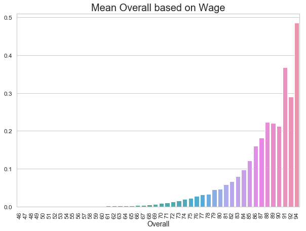

```python
plt.figure(figsize=(10,7))
mean_wage_per_age = ds.groupby('Overall')['Wage'].mean()
p = sns.barplot(x = mean_wage_per_age.index, y = mean_wage_per_age.values)
p = plt.xticks(rotation=90)
plt.title("Mean Overall based on Wage", size=20)
# save_fig("Mean Overall based on Wage.png")
```

Vengono adesso analizzate le posizioni di gioco e come il valore dipenda da esse.

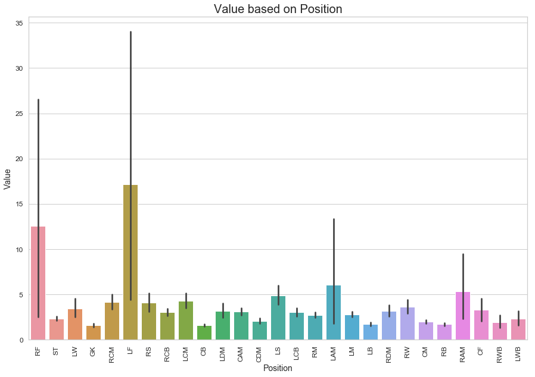

```python
plt.figure(figsize=(15,10))
p = sns.barplot(x = 'Position', y = 'Value', data = ds)
p = plt.xticks(rotation=90)
plt.title("Value based on Position", size=20)
# save_fig("Value based on Position.png")
```

Si semplifica la visualizzazione aggregando le posizioni in 4 ruoli principali: GK, D, M e F, tramite la definizione di una funzione *positionSimplifier*. Per tali rappresentazioni si andrà a lavorare su una copia del dataset.

```python
def positionSimplifier(val):

    if val == 'RF' or val == 'ST' or val == 'LF' or val == 'RS' or val == 'LS' or val == 'CF':
        val = 'F'
        return val

    elif val == 'LW' or val == 'RCM' or val == 'LCM' or val == 'LDM' or val == 'CAM' or val == 'CDM' or val == 'RM' \
         or val == 'LAM' or val == 'LM' or val == 'RDM' or val == 'RW' or val == 'CM' or val == 'RAM':
        val = 'M'
        return val


    elif val == 'RCB' or val == 'CB' or val == 'LCB' or val == 'LB' or val == 'RB' or val == 'RWB' or val == 'LWB':
        val = 'D'
        return val

    else:
        return val
```

```python
ds1 = ds.copy()
ds1['Position'] = ds1['Position'].apply(positionSimplifier)
```

La distribuzione dei giocatori nei quattro ruoli definiti è riportata nel *piechart* di seguito.

[figure not shown]

```python
labels = 'F', 'M', 'GK', 'D'
sizes = ds1['Position'].value_counts()
explode = (0, 0, 0, 0)

fig1, ax1 = plt.subplots()
p = ax1.pie(sizes, explode=explode, labels=labels, autopct='%1.1f%%',
        shadow=True, startangle=90)
ax1.axis('equal')
plt.title("Position Percentage", size=20)
plt.show()
# save_fig("Position Percentage pie-chart.png")
```

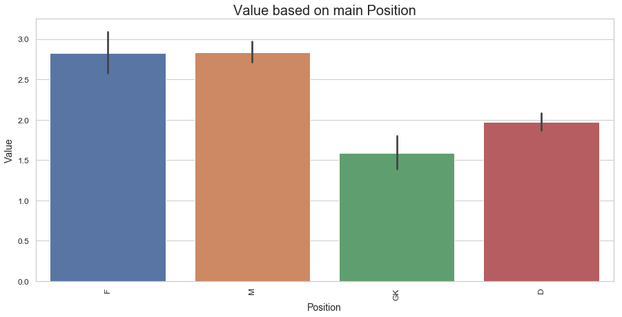

```python
plt.figure(figsize=(15,7))
p = sns.barplot(x = 'Position', y = 'Value', data = ds1)
p = plt.xticks(rotation=90)
plt.title("Value based on main Position", size=20)
# save_fig("Value based on main Position.png")
```

Come ci si aspetta dall'andamento del mercato, un giocatore offensivo ha più valore di uno difensivo. In particolare, i portieri sono quelli col valore più basso, mentre attaccanti e centroncampisti possono valere allo stesso modo. Ciò è anche legato al rapporto tra la posizione e il relativo stipendio, laddove i giocatori offensivi risultano essere i più pagati, come mostrato dal seguente grafico a barre.

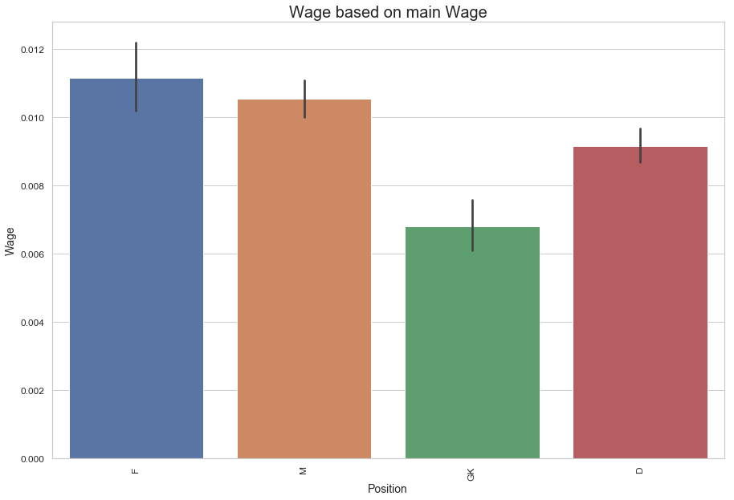

```python
plt.figure(figsize=(15,10))
p = sns.barplot(x = 'Position', y = 'Wage', data = ds1)
p = plt.xticks(rotation=90)
plt.title("Wage based on main Wage", size=20)
# save_fig("Wage based on main Wage.png")
```

Si considerano adesso i campi Contract Valid Until e Release Clause. Infatti, un giocatore con un contratto più duraturo, a parità di condizioni, dovrebbe avere un valore di mercato superiore. Per quanto riguarda la clausola, invece, laddove presente, si può presumere un valore di mercato simile a quello indicato dalla clausola rescissoria concordata dalla società.

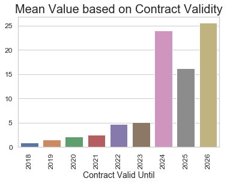

```python
mean_value_per_contract = ds.groupby('Contract Valid Until')['Value'].mean()
p = sns.barplot(x = mean_value_per_contract.index, y = mean_value_per_contract.values)
p = plt.xticks(rotation=90)
plt.title("Mean Value based on Contract Validity", size=20)
# save_fig("Mean Value based on Contract Validity.png")
```

Come si può vedere dal grafico soprastante, giocatori con contratti con scadenza remota hanno una quotazione di mercato maggior rispetto, invece, a giocatori in scadenza a breve. Infatti, per giocatori in scadenza di contratto in genere è possibile abbassare le pretese dell'acquirente.

Un altro aspetto sicuramente da tenere in considerazione è la clausola rescissoria. Infatti, al crescere della clausola si ha un valore di mercato maggiore. Da sottolineare quello che potrebbe sembrare un comportamento inaspettato relativamente al valore di clausola pari a 0, dovuto però alla scelta di sostituire tale valore quando mancante.

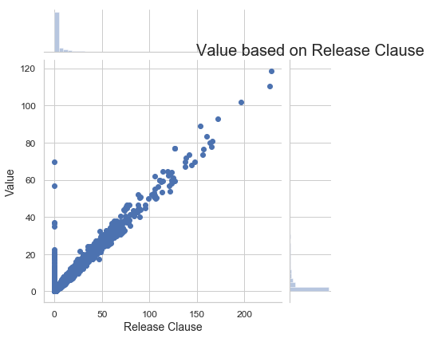

```python
plt.figure(figsize=(20,10))
p = sns.jointplot(x = 'Release Clause', y = 'Value', data = ds)
p = plt.xticks(rotation=90)
plt.title("Value based on Release Clause", size=20)
# save_fig("Value based on Release Clause.png")
```

Si studia, adesso, un possibile legame tra le nazionalità di provenienza di un giocatore e il suo valore. Infatti, la realtà e la storia calcistica dicono che giocatori europei e sudamericani sono in genere i più pagati. Nella rappresentazione vengono considerate le 20 nazioni più rappresentative nel dataset.

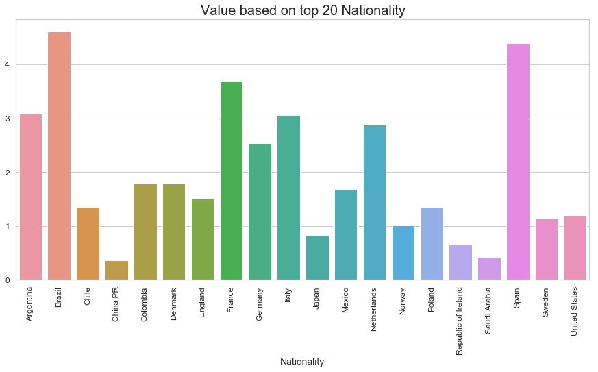

```python
plt.figure(figsize=(15,7))
top_ten_countries = ds['Nationality'].value_counts().head(20).index.values
ds1 = ds.loc[ds['Nationality'].isin(top_ten_countries)]
mean_value_per_nationality = ds1.groupby('Nationality')['Value'].mean()
p = sns.barplot(x = mean_value_per_nationality.index, y = mean_value_per_nationality.values)
p = plt.xticks(rotation=90)
plt.title("Value based on top 20 Nationality", size=20)
# save_fig("Value based on top 20 Nationality.png")
```

Tra i 20 paesi più frequenti nel gioco, i giocatori che appartengono ai paesi con forti culture calcistiche, quali Brasile, Argentina, Francia, Germania, Italia, Olanda, Spagna, ecc., presentano dei valori di mercato maggiori. Il basso valore dell'Inghilterra è legato all'elevata percentuale di giocatori, la maggior parte di serie minori e con bassi overall (e di conseguenza valore di mercato), presenti nel gioco.

Si verifica come varia il valore medio di un giocatore sulla base della reputazione internazionale. L'intuizione porta a pensare che giocatori più famosi avranno valutazione maggiori, come mostrato dal seguente grafico.

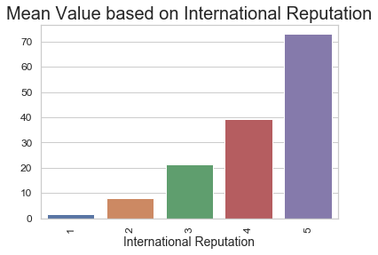

```python
mean_value_per_reputation = ds.groupby('International Reputation')['Value'].mean()
p = sns.barplot(x = mean_value_per_reputation.index, y = mean_value_per_reputation.values)
p = plt.xticks(rotation=90)
plt.title("Mean Value based on International Reputation", size=20)
# save_fig("Mean Value based on International Reputation.png")
```

Infine, si prova a vedere se esiste una qualche relazione tra il valore di mercato e i numeri di maglia dei giocatori. In genere, alcuni numeri sono associati, nella storia calcistica, a particolari posizioni e a giocatori di talento: il 10 per il trequartista di talento, il 9 per il goleador della squadra, l'1 per il portiere, ecc.

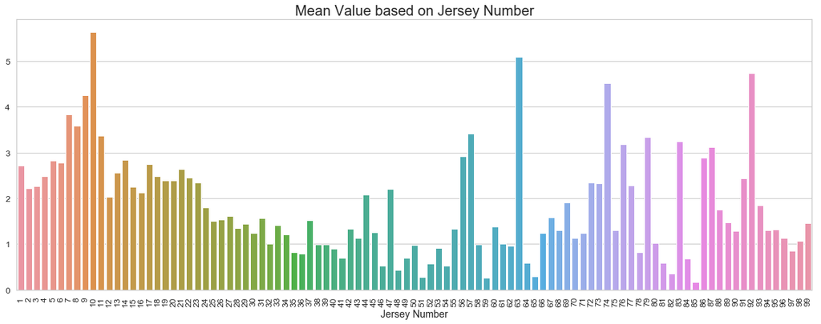

```python
plt.figure(figsize=(20,7))
mean_value_per_jersey = ds.groupby('Jersey Number')['Value'].mean()
p = sns.barplot(x = mean_value_per_jersey.index, y = mean_value_per_jersey.values)
p = plt.xticks(rotation=90)
plt.title("Mean Value based on Jersey Number", size=20)
# save_fig("Mean Value based on Jersey Number.png")
```

Dopo aver condotto l'analisi del valore di mercato tramite grafici, un passo fondamentale a questo punto è lo studio della correlazione tra gli attributi, per verificare se esitono delle relazioni lineari tra gli attributi. Verrà calcolata quindi la matrice di correlazione e osservati i valori rispetto al campo Value.

```python
corr_matrix = ds.corr()
corr_matrix['Value'].sort_values(ascending=False)
```

```
Value                       1.000000
Release Clause              0.967240
Wage                        0.858376
International Reputation    0.653152
Overall                     0.627025
Potential                   0.576606
Reactions                   0.540607
Composure                   0.450381
Vision                      0.357577
ShortPassing                0.327572
BallControl                 0.308818
LongPassing                 0.302080
Volleys                     0.288254
Curve                       0.287208
ShotPower                   0.281381
LongShots                   0.279729
Dribbling                   0.271989
FKAccuracy                  0.265787
Positioning                 0.259391
Finishing                   0.256759
Crossing                    0.249787
LAM                         0.241886
RAM                         0.241886
CAM                         0.241886
RCM                         0.241688
CM                          0.241688
LCM                         0.241688
RF                          0.240833
LF                          0.240833
CF                          0.240833
                              ...
CDM                         0.194069
LDM                         0.194069
RWB                         0.191483
LWB                         0.191483
Aggression                  0.184551
HeadingAccuracy             0.184425
LB                          0.177796
RB                          0.177796
SprintSpeed                 0.172744
Acceleration                0.170677
RCB                         0.153039
LCB                         0.153039
CB                          0.153039
Interceptions               0.140624
Marking                     0.133845
Strength                    0.128792
Jumping                     0.124481
Balance                     0.113841
StandingTackle              0.108366
SlidingTackle               0.087675
Age                         0.075319
Weight                      0.045854
Height                      0.002568
GKPositioning              -0.027918
GKReflexes                 -0.028578
GKDiving                   -0.028619
GKHandling                 -0.028957
GKKicking                  -0.030958
Jersey Number              -0.095132
Joined                     -0.113357
Name: Value, Length: 72, dtype: float64
```

Dalla correlazione si notano quali sono gli attributi da tenere in considerazione per determinare il valore di mercato di un giocatore. In particolare, oltre alle variabili già individuate in maniera grafica, quali Release Clause, Wage, International Reputation, Overall,Potential, si nota una correlazione abbastanza elevata con gli attributi Reaction, Composure e Vision, che verranno quindi presi in considerazione, mentre sembra non esservene con l'età, che invece era stata considerata. I valori delle varie posizioni (LAM, RAM, CAM, ecc.), invece, hanno valori di correlazione che sono surclassati comunque dall'overall, motivo per cui non verrano considerati. Per quanto riguarda l'attributo Age, invece, nonostante non sembri avere una buona correlazione con Value, si decide comunque di considerarlo nel processo di regressione perchè si ritiene comunque importante e considerando che la correlazione è in grado di rilevare solo nelle relazioni di tipo lineare, non cogliendo, invece, altri tipo di relazioni.

```python
ds1 = ds.copy()
colToUse = ['Overall','Release Clause', 'Wage','International Reputation', 'Potential','Reactions','Composure','Age','Vision','Contract Valid Until', 'Club', 'Position','Nationality','Value']
ds = ds[colToUse]
```

Si mostra la correlazione da un punto di vista grafico.

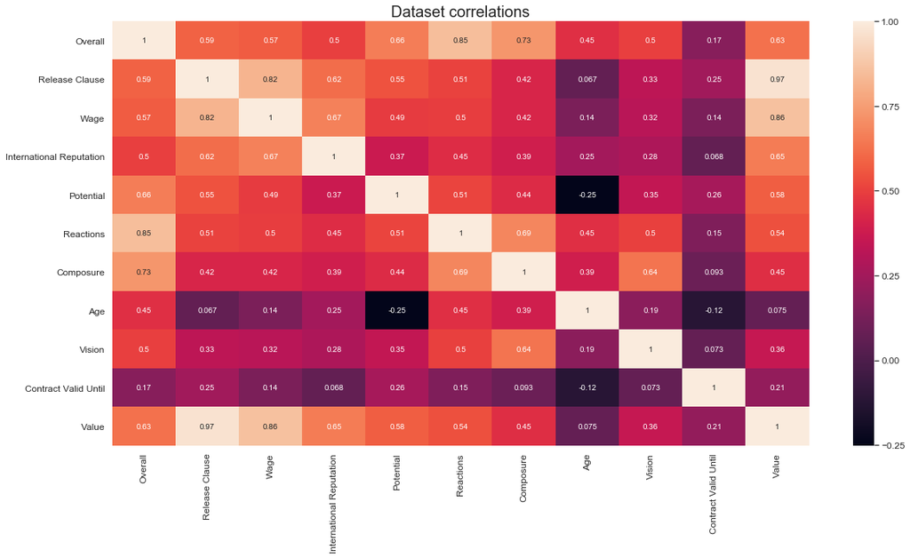

```python
fig,ax = plt.subplots(figsize=(20,10))
fig = sns.heatmap(ds.corr(), annot=True)
plt.title("Dataset correlations", size=20)
plt.show()
# figure = fig.get_figure()
# save_figure(figure, "Dataset correlations")
```

Un ultimo passo è, una volta studiate le correlazioni tra gli attributi, capire effettivamente quali sono quelli più rilevanti. Per farlo, il dataset è trasformato usando il LabelEncoder, che codifica il dataset con delle etichette numeriche. Successivamente è possibile applicare il Random Forest per determinare gli attributi con maggiore importanza per la predizione del campo Value. Si lavorerà sul dataset ds2, copia del dataset originale prima delle scelta degli attributi.

```python
from sklearn.preprocessing import LabelEncoder
Encoder_df = LabelEncoder()
ds2 = ds1.copy()

for c in ds2.columns:
    ds2[c] = Encoder_df.fit_transform(ds2[c])
```

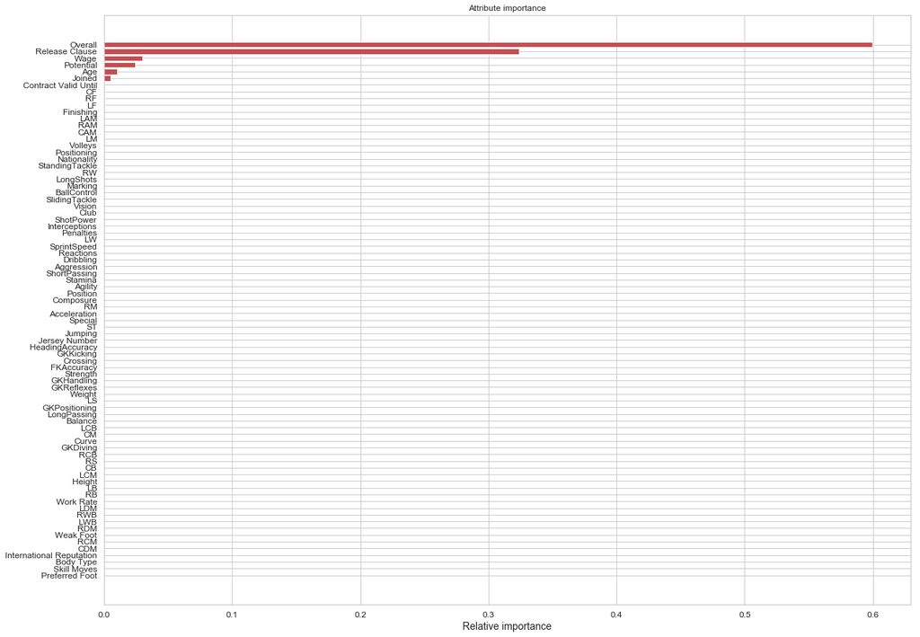

```python
from sklearn.ensemble import RandomForestRegressor
ds2X = ds2.drop('Value', axis = 1)
ds2y = ds2['Value']

rnd_reg = RandomForestRegressor(n_estimators=40, n_jobs=-1, random_state=40)
rnd_reg.fit(ds2X, ds2y)
attributes = ds2X.columns
importances = rnd_reg.feature_importances_
index = np.argsort(importances)

plt.figure(figsize=(20,15))
plt.title("Attribute importance")
p = plt.barh(range(len(index)), importances[index], color='r', align='center')
plt.yticks(range(len(index)), attributes[index])
plt.xlabel("Relative importance")
plt.show()
# save_fig("Attribute importance")
```

## TRANSFORMATION

Dopo aver determinato gli attributi da usare nel processo di regressione, si provvede a preparare i dati da passare agli algoritmi di machine learning. In particolare le trasformazioni che seguiranno non rientrano nel data cleaning, che invece è stato effettuato a monte, quanto principalmente la discretizzazione, l'omogeneizzazione e la codifica dei dati.

Si osserva la presenza di 164 nazioni. La più rappresentata è l'England, con 1657 giocatori, mentre si nota la presenza di molte nazioni con pochissimi giocatori rappresentanti, a volte anche 1 solo. Per facilitare la gestione di questo attributo categorico nominale, si è scelto di accorpare le nazioni che non superano una soglia di 22 giocatori (numero minimo per una squadra) in un'unica nazione chiamata 'Other'.

```python
ds.Nationality.unique()
```

```
array(['Argentina', 'Portugal', 'Brazil', 'Spain', 'Belgium', 'Croatia',
       'Uruguay', 'Slovenia', 'Poland', 'Germany', 'France', 'England',
       'Italy', 'Egypt', 'Colombia', 'Denmark', 'Gabon', 'Wales',
       'Senegal', 'Costa Rica', 'Slovakia', 'Netherlands',
       'Bosnia Herzegovina', 'Morocco', 'Serbia', 'Algeria', 'Austria',
       'Greece', 'Chile', 'Sweden', 'Korea Republic', 'Finland', 'Guinea',
       'Montenegro', 'Armenia', 'Switzerland', 'Norway', 'Czech Republic',
       'Scotland', 'Ghana', 'Central African Rep.', 'DR Congo',
       'Ivory Coast', 'Russia', 'Ukraine', 'Iceland', 'Mexico', 'Jamaica',
       'Albania', 'Venezuela', 'Japan', 'Turkey', 'Ecuador', 'Paraguay',
       'Mali', 'Nigeria', 'Cameroon', 'Dominican Republic', 'Israel',
       'Kenya', 'Hungary', 'Republic of Ireland', 'Romania',
       'United States', 'Cape Verde', 'Australia', 'Peru', 'Togo',
       'Syria', 'Zimbabwe', 'Angola', 'Burkina Faso', 'Iran', 'Estonia',
       'Tunisia', 'Equatorial Guinea', 'New Zealand', 'FYR Macedonia',
       'United Arab Emirates', 'China PR', 'Guinea Bissau', 'Bulgaria',
       'Kosovo', 'South Africa', 'Madagascar', 'Georgia', 'Tanzania',
       'Gambia', 'Cuba', 'Belarus', 'Uzbekistan', 'Benin', 'Congo',
       'Mozambique', 'Honduras', 'Canada', 'Northern Ireland', 'Cyprus',
       'Saudi Arabia', 'Curacao', 'Moldova', 'Bolivia',
       'Trinidad & Tobago', 'Sierra Leone', 'Zambia', 'Chad',
       'Philippines', 'Haiti', 'Comoros', 'Libya', 'Panama',
       'São Tomé & Príncipe', 'Eritrea', 'Oman', 'Iraq', 'Burundi',
       'Fiji', 'New Caledonia', 'Lithuania', 'Luxembourg', 'Korea DPR',
       'Liechtenstein', 'St Kitts Nevis', 'Latvia', 'Suriname', 'Uganda',
       'El Salvador', 'Bermuda', 'Kuwait', 'Antigua & Barbuda',
       'Thailand', 'Mauritius', 'Guatemala', 'Liberia', 'Kazakhstan',
       'Niger', 'Mauritania', 'Montserrat', 'Namibia', 'Azerbaijan',
       'Guam', 'Faroe Islands', 'India', 'Nicaragua', 'Barbados',
       'Lebanon', 'Palestine', 'Guyana', 'Sudan', 'St Lucia', 'Ethiopia',
       'Puerto Rico', 'Grenada', 'Jordan', 'Rwanda', 'Qatar',
       'Afghanistan', 'Hong Kong', 'Andorra', 'Malta', 'Belize',
       'South Sudan', 'Indonesia', 'Botswana'], dtype=object)
```

```python
ds['Nationality'].value_counts().head()
```

```
England      1657
Germany      1195
Spain        1071
Argentina     936
France        911
Name: Nationality, dtype: int64
```

```python
naz = ds.groupby('Nationality').filter(lambda x: len(x) < 22)['Nationality'].unique()
ds.loc[ds.Nationality.isin(naz), 'Nationality'] = 'Other'
len(naz)
```

```
91
```

Si accorpano, così, ben 91 nazioni.

Un altro problema che porta ad un'elevata dimensionalità del dataset riguarda la presenza di oltre 600 Club. Si è scelto, pertanto, di rimappare i Club con un valore compreso tra 0.5 e 5 a passi di 0.5, come avviene effettivamente nel gioco, dove ogni squadra ha assegnato delle stelle (*rating*). Infatti, un giocatore appartenente ad una squadra con 5 stelle avrà, quasi nella totalità dei casi, un valore maggiore di uno che appartiene ad una squadra di 0.5 stelle. Inoltre, non è d'interesse differenziare tra un giocatore appartenente al Barcelona o alla Juventus (entrambi top club) quanto, piuttosto, discriminare tra una squadra top e una no. Viene rappresentata la distribuzione del valore dopo la mappatura, analisi che precedentemente non era stato possibile condurre per l'eccesivo numero di club.

```python
ds['Club'].value_counts()
ds.groupby('Club')['Overall'].median().sort_values(ascending=False).head()
```

```
Club
Juventus             84.0
FC Bayern München    83.0
FC Barcelona         82.0
Atlético Madrid      81.0
Manchester City      81.0
Name: Overall, dtype: float64
```

```python
club_rating = ps.cut(ds.groupby('Club')['Overall'].median(), 10, labels = [0.5,1,1.5,2,2.5,3,3.5,4,4.5,5])
ds['Club']=ds['Club'].map(club_rating)
ds.head()
```

|  | Overall | Release Clause | Wage | International Reputation | Potential | Reactions | Composure | Age | Vision | Contract Valid Until | Club | Position | Nationality | Value |
| --- | --- | --- | --- | --- | --- | --- | --- | --- | --- | --- | --- | --- | --- | --- |
| 0 | 94 | 226.5 | 0.565 | 5 | 94 | 95 | 96 | 31 | 94 | 2021 | 5.0 | RF | Argentina | 110.5 |
| 1 | 94 | 127.1 | 0.405 | 5 | 94 | 96 | 95 | 33 | 82 | 2022 | 5.0 | ST | Portugal | 77.0 |
| 2 | 92 | 228.1 | 0.290 | 5 | 93 | 94 | 94 | 26 | 87 | 2022 | 4.5 | LW | Brazil | 118.5 |
| 3 | 91 | 138.6 | 0.260 | 4 | 93 | 90 | 68 | 27 | 68 | 2020 | 4.5 | GK | Spain | 72.0 |
| 4 | 91 | 196.4 | 0.355 | 4 | 92 | 91 | 88 | 27 | 94 | 2023 | 4.5 | RCM | Belgium | 102.0 |

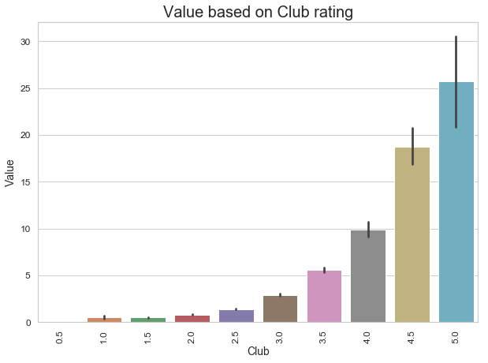

```python
plt.figure(figsize=(10,7))
p = sns.barplot(x = 'Club', y = 'Value', data = ds)
p = plt.xticks(rotation=90)
plt.title("Value based on Club rating", size=20)
# save_fig("Value based on Club rating")
```

Si procede adesso alla discretizzazione e codifica del dataset.

```python
from sklearn.preprocessing import OneHotEncoder, KBinsDiscretizer, StandardScaler, OrdinalEncoder
from sklearn.impute import SimpleImputer
from sklearn.pipeline import Pipeline
```

Innanzitutto occorre separare il dataset con gli attributi da usare per il processo di regressione (Xds) e il dataset composto solo dall'attributo target (yds). Successivamente questi due subset verrano splitatti nei definiti train_set e test_set.

```python
Xds, yds = ds.loc[:, ['Overall','Release Clause', 'Wage','International Reputation', 'Potential','Reactions','Composure','Age','Vision','Contract Valid Until', 'Club', 'Position','Nationality']
], ds.loc[:,["Value"]]
```

Si defiscono le trasformazioni ncessarie. In particolare, per gli attributi International Reputation e Age (int64) si provvede alla discretizzazione in 5 intervalli usando la OneHotEncode; per gli attributi Overall, Potential, Reactions, Composure e Vision, invece, pur essendo sempre di tipo intero, si è scelto una discretizzazione in 5 bins basata su una strategia uniforme, in modo che tutti i bins in ogni attributo abbiano la stessa grandezza; per gli attributi categorici Nationality e Position si è scelto, invece, una codifica di tipo OrdinalEconder; infine, Nationality, Position e Club vengono anche codificati tramite la OneHotEncoder.

```python
discretizeInt = KBinsDiscretizer(n_bins=5, encode='onehot') #discretizza international reputation e age
discretizeVals = KBinsDiscretizer(n_bins=5, encode='onehot',strategy = 'uniform') #discretizza overall, potential, reactions, composure, vision in 5 bins
ordinalEncoderNatPos = OrdinalEncoder() #econding nationality e position
oneHot = OneHotEncoder(sparse = False) #hoteconder per nationality position e club
```

Vengono quindi realizzate le trasformazioni tramite la funzione *fit_transform*, viene costruita una Pipeline per ognuna delle trasformazioni da effettuare e infine viene eseguita tutta la Pipeline realizzata.

```python
ordinalEncoderNat = OrdinalEncoder() #econding Nationality
nat_encoded = ordinalEncoderNat.fit_transform(ds[["Nationality"]])
nat_encoded[:10]
```

```
array([[ 2.],
       [53.],
       [ 8.],
       [64.],
       [ 5.],
       [ 5.],
       [17.],
       [71.],
       [64.],
       [62.]])
```

```python
ordinalEncoderPos = OrdinalEncoder() #econding Position
pos_encoded = ordinalEncoderPos.fit_transform(ds[["Position"]])
pos_encoded[:10]
```

```
array([[21.],
       [26.],
       [14.],
       [ 5.],
       [19.],
       [11.],
       [19.],
       [23.],
       [18.],
       [ 5.]])
```

```python
IR_Age = ["International Reputation", "Age"]
vals = ["Overall", "Potential", "Reactions", "Composure", "Vision"]

pipe1 = Pipeline([
        ('discretize',discretizeInt)
    ])
pipe1_res = pipe1.fit_transform(ds[IR_Age])

pipe2 = Pipeline([
        ('discretize', discretizeVals)
    ])
pipe2_res = pipe2.fit_transform(ds[vals])


pipe3 = Pipeline([
        ('ordinal', ordinalEncoderNat),
        ('onehot',oneHot)
    ])
pipe3_res = pipe3.fit_transform(ds[["Nationality"]])


pipe4 = Pipeline([
        ('ordinal', ordinalEncoderPos),
        ('onehot',oneHot)
    ])
pipe4_res = pipe4.fit_transform(ds[["Position"]])

pipe5 = Pipeline([
    ('onehot',oneHot)
    ])
pipe5_res = pipe5.fit_transform(ds[["Club"]])
```

```python
from sklearn.compose import ColumnTransformer

full_pipeline = ColumnTransformer([
       ("pipe1", pipe1, IR_Age),
        ("pipe2", pipe2, vals),
        ("pipe3", pipe3, ["Nationality"]),
        ("pipe4", pipe4, ["Position"]),
        ("pipe5", pipe5, ["Club"])],remainder='passthrough')

X, Y = full_pipeline.fit_transform(Xds), yds.values.reshape(-1)
```

A questo punto, X e Y sono i due set codificati.

```python
X = X.astype('int')
Y = Y.astype('int')
print(X)
print(hrule(40))
print(Y)
```

```
[[   0    0    0 ...  226    0 2021]
 [   0    0    0 ...  127    0 2022]
 [   0    0    0 ...  228    0 2022]
 ...
 [   0    0    0 ...    0    0 2021]
 [   0    0    0 ...    0    0 2019]
 [   0    0    0 ...    0    0 2019]]
========================================
[110  77 118 ...   0   0   0]
```

## ALGORITMI DI REGRESSIONE

Arrivati a questo punto è possibile creare i train e test set e procedere all'addestramento degli algoritmi di machine learning. Per determinare i set viene usata la funzione *train_test_split*, con la dimensione del test_set pari al 20% del dataset totale.

```python
from sklearn.model_selection import train_test_split
from sklearn.model_selection import cross_val_score

X_train, X_test,  y_train, y_test = train_test_split(X,Y, test_size=0.2)
print(X_train.shape, y_train.shape, X_test.shape, y_test.shape)
```

```
(14517, 145) (14517,) (3630, 145) (3630,)
```

Si definisce una funzione *compute_performance* per determinare alcuni score per valutare la bontà dei modelli. In particolare, nel caso della regressione, non si calcolano i classici valori di accuracy, precision e recall, ma si usano altre metriche:

- variance_score (migliore possibile 1.0, minore è peggio)

  $$

  ```
    variance(y, \hat{y}) = 1 - \frac{Var\{ y - \hat{y}\}}{Var\{y\}}
  ```

  $$
- mean_absolute_error

  $$

  $$

  $$

  ```
  \text{MLSE}(y, \hat{y}) = \sqrt{\frac{1}{n_\text{samples}} \sum_{i=0}^{n_\text{samples} - 1} (log(y_i) - \hat log({y}_i))^2}
  ```

  $$
- median_absolute_error

  $$ \text{MedAE}(y, \hat{y}) = \text{median}(\mid y_1 - \hat{y}_1 \mid, \ldots, \mid y_n - \hat{y}_n \mid). $$
- r2_score (migliore possibile 1.0, può assumere valori negativi per modelli non buoni)

  $$ R^2(y, \hat{y}) = 1 - \frac{\sum_{i=1}^{n} (y_i - \hat{y}_i)^2}{\sum_{i=1}^{n} (y_i - \bar{y})^2} $$

```python
from sklearn.model_selection import cross_val_predict, cross_val_score
from sklearn.metrics import*
import time

ps.options.display.float_format = '{:.8f}'.format

def compute_performance(classifiers,names,X,y):
    score_dict = {}
    score_dict['Classifier'] = {}
    score_dict['mse'] = {}
    score_dict['variance']= {}
    score_dict['mae']= {}
    score_dict['median_se']= {}
    score_dict['r2']= {}


    for i in range(len(classifiers)):
        value_predictions = classifiers[i].predict(X)
        mse = mean_squared_error(y, value_predictions)
        variance = explained_variance_score(y,value_predictions)
        mae = mean_absolute_error(y,value_predictions)
        median_se = median_absolute_error(y, value_predictions)
        r2 = r2_score(y, value_predictions)

        name = names[i]

        score_dict['Classifier'][i] = name
        score_dict['mse'][i] = mse
        score_dict['variance'][i] = variance
        score_dict['mae'][i] = mae
        score_dict['median_se'][i] = median_se
        score_dict['r2'][i] = r2

    return score_dict
```

Laddove i regressori presentino degli iperparametri (valori impostabili dall'utente) si esegue prima l'algoritmo con i valori di default e successivamente, tramite Grid Search, si determinano gli iperparametri migliori per quel specifico algoritmo.

```python
from sklearn.model_selection import GridSearchCV
import pickle
```

```python
regressors = []
names = []
```

# Linear Models

```python
linear_models = []
```

## Linear Regressor

```python
from sklearn.linear_model import LinearRegression

# lin_reg = LinearRegression()
# lin_reg = lin_reg.fit(X_train, y_train)

# # save the model to disk
# filename = 'lin_reg.sav'
# pickle.dump(lin_reg, open(filename, 'wb'))

# load the model from disk
filename = './Models/lin_reg.sav'
lin_reg = pickle.load(open(filename, 'rb'))
print(lin_reg)
```

```
LinearRegression(copy_X=True, fit_intercept=True, n_jobs=None,
         normalize=False)
```

```python
# from sklearn.model_selection import cross_val_score
# lin_regscores = cross_val_score(lin_reg, X_train, y_train,scoring="neg_mean_squared_error", cv=10)
# rmse_scores = np.sqrt(-lin_regscores)

# print("Scores:", rmse_scores)
# print("Mean: ", rmse_scores.mean())
# print("Std.: ", rmse_scores.std())
# compute_performance([lin_reg],["Linear Regressors"],X_train, y_train, score_dict_train)
# compute_performance([lin_reg],["Linear Regressors"], X_test, y_test, score_dict_test)
```

```python
regressors.append(lin_reg)
names.append("Linear Regressor")
linear_models.append("Linear Regressor")
```

## Huber Regressor

```python
from sklearn.linear_model import HuberRegressor

# huber_reg = HuberRegressor()
# huber_reg.fit(X_train, y_train)

# # save the model to disk
# filename = 'huber_reg.sav'
# pickle.dump(huber_reg, open(filename, 'wb'))

# load the model from disk
filename = './Models/huber_reg.sav'
huber_reg = pickle.load(open(filename, 'rb'))
print(huber_reg)
```

```
HuberRegressor(alpha=0.0001, epsilon=1.35, fit_intercept=True, max_iter=100,
        tol=1e-05, warm_start=False)
```

```python
regressors.append(huber_reg)
names.append("Huber Regressor")
linear_models.append("Huber Regressor")
```

## SGD Regressor

```python
# your code here
from sklearn.linear_model import SGDRegressor

# sgd_reg = SGDRegressor(random_state=42)
# sgd_reg.fit(X_train, y_train)

# # save the model to disk
# filename = 'sgd_reg.sav'
# pickle.dump(sgd_reg, open(filename, 'wb'))

# load the model from disk
filename = './Models/sgd_reg.sav'
sgd_reg = pickle.load(open(filename, 'rb'))
print(sgd_reg)
```

```
SGDRegressor(alpha=0.0001, average=False, early_stopping=False, epsilon=0.1,
       eta0=0.01, fit_intercept=True, l1_ratio=0.15,
       learning_rate='invscaling', loss='squared_loss', max_iter=None,
       n_iter=None, n_iter_no_change=5, penalty='l2', power_t=0.25,
       random_state=42, shuffle=True, tol=None, validation_fraction=0.1,
       verbose=0, warm_start=False)
```

```python
regressors.append(sgd_reg)
names.append("SGD Regressor")
linear_models.append("SGD Regressor")
```

```python
# sgd_params_grid = {
#     'loss': ['squared_loss', 'huber', 'epsilon_insensitive', 'squared_epsilon_insensitive'],
#     'penalty': ['l2','elasticnet', 'l1'],
#     'alpha' : [0.0001, 0.005, 0.01, 0.1, 0.2]}

# sgd_grid_search = GridSearchCV(sgd_reg, sgd_params_grid, cv=5,
#                            scoring='neg_mean_squared_error', return_train_score=True)
# sgd_grid_search.fit(X_train, y_train)
# best_sgd_params = sgd_grid_search.best_estimator_
# best_sgd_params
```

```python
# # save the model to disk
# filename = 'sgd_grid_search.sav'
# pickle.dump(sgd_grid_search, open(filename, 'wb'))

# load the model from disk
filename = './Models/sgd_grid_search.sav'
sgd_grid_search = pickle.load(open(filename, 'rb'))
print(sgd_grid_search)
```

```
GridSearchCV(cv=5, error_score='raise-deprecating',
       estimator=SGDRegressor(alpha=0.0001, average=False, early_stopping=False, epsilon=0.1,
       eta0=0.01, fit_intercept=True, l1_ratio=0.15,
       learning_rate='invscaling', loss='squared_loss', max_iter=None,
       n_iter=None, n_iter_no_change=5, penalty='l2', power_t=0.25,
       random_state=42, shuffle=True, tol=None, validation_fraction=0.1,
       verbose=0, warm_start=False),
       fit_params=None, iid='warn', n_jobs=None,
       param_grid={'loss': ['squared_loss', 'huber', 'epsilon_insensitive', 'squared_epsilon_insensitive'], 'penalty': ['l2', 'elasticnet', 'l1'], 'alpha': [0.0001, 0.005, 0.01, 0.1, 0.2]},
       pre_dispatch='2*n_jobs', refit=True, return_train_score=True,
       scoring='neg_mean_squared_error', verbose=0)
```

```python
regressors.append(sgd_grid_search)
names.append("SGD Regressor Grid")
linear_models.append("SGD Regressor Grid")
```

## Bayesian Ridge Regressor

```python
from sklearn.linear_model import BayesianRidge

# bay_reg = BayesianRidge()
# bay_reg.fit(X_train, y_train)

# # save the model to disk
# filename = './Models/bay_reg.sav'
# pickle.dump(bay_reg, open(filename, 'wb'))

# load the model from disk
filename = './Models/bay_reg.sav'
bay_reg = pickle.load(open(filename, 'rb'))
print(bay_reg)
```

```
BayesianRidge(alpha_1=1e-06, alpha_2=1e-06, compute_score=False, copy_X=True,
       fit_intercept=True, lambda_1=1e-06, lambda_2=1e-06, n_iter=300,
       normalize=False, tol=0.001, verbose=False)
```

```python
regressors.append(bay_reg)
names.append("Bayesian Ridge Regressor")
linear_models.append("Bayesian Ridge Regressor")
```

# Tree Models

```python
tree_models = []
```

## DecisionTreeRegressor

```python
from sklearn.tree import DecisionTreeRegressor

# tree_reg = DecisionTreeRegressor(random_state=42)
# tree_reg.fit(X_train, y_train)

# # save the model to disk
# filename = './Models/tree_reg.sav'
# pickle.dump(tree_reg, open(filename, 'wb'))

# load the model from disk
filename = './Models/tree_reg.sav'
tree_reg = pickle.load(open(filename, 'rb'))
print(tree_reg)
```

```
DecisionTreeRegressor(criterion='mse', max_depth=None, max_features=None,
           max_leaf_nodes=None, min_impurity_decrease=0.0,
           min_impurity_split=None, min_samples_leaf=1,
           min_samples_split=2, min_weight_fraction_leaf=0.0,
           presort=False, random_state=42, splitter='best')
```

```python
regressors.append(tree_reg)
names.append("Tree Regressor")
tree_models.append("Tree Regressor")
```

```python
# tree_params_grid = {
#     'criterion': ['mse', 'friedman_mse', 'mae'],
#     'splitter': ['best', 'random']
# }

# tree_grid_search = GridSearchCV(tree_reg, tree_params_grid, cv=5,
#                            scoring='neg_mean_squared_error', return_train_score=True)
# tree_grid_search.fit(X_train, y_train)
# best_tree_params = tree_grid_search.best_estimator_
# best_tree_params
```

```python
# # save the model to disk
# filename = './Models/tree_grid_search.sav'
# pickle.dump(tree_grid_search, open(filename, 'wb'))

# load the model from disk
filename = './Models/tree_grid_search.sav'
tree_grid_search = pickle.load(open(filename, 'rb'))
print(tree_grid_search)
```

```
GridSearchCV(cv=5, error_score='raise-deprecating',
       estimator=DecisionTreeRegressor(criterion='mse', max_depth=None, max_features=None,
           max_leaf_nodes=None, min_impurity_decrease=0.0,
           min_impurity_split=None, min_samples_leaf=1,
           min_samples_split=2, min_weight_fraction_leaf=0.0,
           presort=False, random_state=42, splitter='best'),
       fit_params=None, iid='warn', n_jobs=None,
       param_grid={'criterion': ['mse', 'friedman_mse', 'mae'], 'splitter': ['best', 'random']},
       pre_dispatch='2*n_jobs', refit=True, return_train_score=True,
       scoring='neg_mean_squared_error', verbose=0)
```

```python
regressors.append(tree_grid_search)
names.append("Tree Regressor Grid")
tree_models.append("Tree Regressor Grid")
```

## ExtraTreeRegressor

```python
# your code here
from sklearn.tree import ExtraTreeRegressor

# extra_tree_reg = ExtraTreeRegressor(random_state=42)
# extra_tree_reg.fit(X_train, y_train)

# # save the model to disk
# filename = './Models/extra_tree_reg.sav'
# pickle.dump(extra_tree_reg, open(filename, 'wb'))

# load the model from disk
filename = './Models/extra_tree_reg.sav'
extra_tree_reg = pickle.load(open(filename, 'rb'))
print(extra_tree_reg)
```

```
ExtraTreeRegressor(criterion='mse', max_depth=None, max_features='auto',
          max_leaf_nodes=None, min_impurity_decrease=0.0,
          min_impurity_split=None, min_samples_leaf=1, min_samples_split=2,
          min_weight_fraction_leaf=0.0, random_state=42, splitter='random')
```

```python
regressors.append(extra_tree_reg)
names.append("Extra Tree Regressor")
tree_models.append("Extra Tree Regressor")
```

```python
# extra_tree_params_grid = {
#     'criterion': ['mse', 'friedman_mse', 'mae'],
#     'splitter': ['best', 'random']
# }

# extra_tree_grid_search = GridSearchCV(extra_tree_reg, extra_tree_params_grid, cv=5,
#                            scoring='neg_mean_squared_error', return_train_score=True)
# extra_tree_grid_search.fit(X_train, y_train)
# best_extra_tree_params = extra_tree_grid_search.best_estimator_
# best_extra_tree_params
```

```python
# # save the model to disk
# filename = './Models/extra_tree_grid_search.sav'
# pickle.dump(extra_tree_grid_search, open(filename, 'wb'))

# load the model from disk
filename = './Models/extra_tree_grid_search.sav'
extra_tree_grid_search = pickle.load(open(filename, 'rb'))
print(extra_tree_grid_search)
```

```
GridSearchCV(cv=5, error_score='raise-deprecating',
       estimator=ExtraTreeRegressor(criterion='mse', max_depth=None, max_features='auto',
          max_leaf_nodes=None, min_impurity_decrease=0.0,
          min_impurity_split=None, min_samples_leaf=1, min_samples_split=2,
          min_weight_fraction_leaf=0.0, random_state=42, splitter='random'),
       fit_params=None, iid='warn', n_jobs=None,
       param_grid={'criterion': ['mse', 'friedman_mse', 'mae'], 'splitter': ['best', 'random']},
       pre_dispatch='2*n_jobs', refit=True, return_train_score=True,
       scoring='neg_mean_squared_error', verbose=0)
```

```python
regressors.append(extra_tree_grid_search)
names.append("Extra Tree Regressor Grid")
tree_models.append("Extra Tree Regressor Grid")
```

# Instance based Regressors

```python
instance_based = []
```

## K Neighbour Regressor

```python
from sklearn.neighbors import KNeighborsRegressor

# kn_reg = KNeighborsRegressor()
# kn_reg.fit(X_train, y_train)


# # save the model to disk
# filename = './Models/kn_reg.sav'
# pickle.dump(kn_reg, open(filename, 'wb'))

# load the model from disk
filename = './Models/kn_reg.sav'
kn_reg = pickle.load(open(filename, 'rb'))
print(kn_reg)
```

```
KNeighborsRegressor(algorithm='auto', leaf_size=30, metric='minkowski',
          metric_params=None, n_jobs=None, n_neighbors=5, p=2,
          weights='uniform')
```

```python
regressors.append(kn_reg)
names.append("K Neighbor Regressor")
instance_based.append("K Neighbor Regressor")
```

```python
# kn_params_grid = {
#      'n_neighbors': [5,10,15,20,50],
#     'weights': ['uniform','distance'],
#     'leaf_size': [20,30,50]
# }

# kn_grid_search = GridSearchCV(kn_reg, kn_params_grid, cv=5,
#                            scoring='neg_mean_squared_error', return_train_score=True)
# kn_grid_search.fit(X_train, y_train)
# best_kn_params = kn_grid_search.best_estimator_
# best_kn_params
```

```python
# # save the model to disk
# filename = './Models/kn_grid_search.sav'
# pickle.dump(kn_reg, open(filename, 'wb'))

# load the model from disk
filename = './Models/kn_grid_search.sav'
kn_grid_search = pickle.load(open(filename, 'rb'))
print(kn_grid_search)
```

```
KNeighborsRegressor(algorithm='auto', leaf_size=30, metric='minkowski',
          metric_params=None, n_jobs=None, n_neighbors=5, p=2,
          weights='uniform')
```

```python
regressors.append(kn_grid_search)
names.append("K Neighbor Regressor Grid")
instance_based.append("K Neighbor Regressor Grid")
```

## Radius Neighbors Regressor

```python
from sklearn.neighbors import RadiusNeighborsRegressor

# radius_n_reg = RadiusNeighborsRegressor()
# radius_n_reg.fit(X_train, y_train)

# # save the model to disk
# filename = './Models/radius_n_reg.sav'
# pickle.dump(radius_n_reg, open(filename, 'wb'))

# load the model from disk
filename = './Models/radius_n_reg.sav'
radius_n_reg = pickle.load(open(filename, 'rb'))
print(radius_n_reg)
```

```
RadiusNeighborsRegressor(algorithm='auto', leaf_size=30, metric='minkowski',
             metric_params=None, n_jobs=None, p=2, radius=1.0,
             weights='uniform')
```

```python
regressors.append(radius_n_reg)
names.append("Radius Neighbor Regressor")
instance_based.append("Radius Neighbor Regressor")
```

# Ensemble Models

```python
ensemble_models = []
```

## Random Forest

```python
# create and train the model
from sklearn.ensemble import RandomForestRegressor

# forest_reg = RandomForestRegressor(n_estimators=10, random_state=42)
# forest_reg.fit(X_train, y_train)

# # save the model to disk
# filename = './Models/forest_reg.sav'
# pickle.dump(forest_reg, open(filename, 'wb'))

# load the model from disk
filename = './Models/forest_reg.sav'
forest_reg = pickle.load(open(filename, 'rb'))
print(forest_reg)
```

```
RandomForestRegressor(bootstrap=True, criterion='mse', max_depth=None,
           max_features='auto', max_leaf_nodes=None,
           min_impurity_decrease=0.0, min_impurity_split=None,
           min_samples_leaf=1, min_samples_split=2,
           min_weight_fraction_leaf=0.0, n_estimators=10, n_jobs=None,
           oob_score=False, random_state=42, verbose=0, warm_start=False)
```

```python
regressors.append(forest_reg)
names.append("Forest Regressor")
ensemble_models.append("Forest Regressor")
```

Dati i diversi parametri da dover fornire in input per il corretto funzionamento del Random Forest, si può usare Grid Search per determinare i parametri migliori, andando ad esplorare le diverse combinazioni.

```python
# forest_param_grid = [
#     {'n_estimators': [3, 10, 30,100], 'max_features': [2, 4, 6, 8,10]},
#     {'bootstrap': [False], 'n_estimators': [3, 10], 'max_features': [2, 3, 4]},
#   ]


# forest_grid_search = GridSearchCV(forest_reg, forest_param_grid, cv=5,
#                            scoring='neg_mean_squared_error', return_train_score=True)
# forest_grid_search.fit(X_train, y_train)
# best_forest_params = forest_grid_search.best_estimator_
# best_forest_params
```

```python
# # save the model to disk
# filename = './Models/forest_grid_search.sav'
# pickle.dump(forest_grid_search, open(filename, 'wb'))

# load the model from disk
filename = './Models/forest_grid_search.sav'
forest_grid_search = pickle.load(open(filename, 'rb'))
print(forest_grid_search)
```

```
GridSearchCV(cv=5, error_score='raise-deprecating',
       estimator=RandomForestRegressor(bootstrap=True, criterion='mse', max_depth=None,
           max_features='auto', max_leaf_nodes=None,
           min_impurity_decrease=0.0, min_impurity_split=None,
           min_samples_leaf=1, min_samples_split=2,
           min_weight_fraction_leaf=0.0, n_estimators=10, n_jobs=None,
           oob_score=False, random_state=42, verbose=0, warm_start=False),
       fit_params=None, iid='warn', n_jobs=None,
       param_grid=[{'n_estimators': [3, 10, 30, 100], 'max_features': [2, 4, 6, 8, 10]}, {'bootstrap': [False], 'n_estimators': [3, 10], 'max_features': [2, 3, 4]}],
       pre_dispatch='2*n_jobs', refit=True, return_train_score=True,
       scoring='neg_mean_squared_error', verbose=0)
```

```python
regressors.append(forest_grid_search)
names.append("Forest Regressor Grid")
ensemble_models.append("Forest Regressor Grid")
```

## AdaBoost Regressor

```python
from sklearn.ensemble import AdaBoostRegressor

# ada_reg = AdaBoostRegressor()
# ada_reg.fit(X_train, y_train)

# # save the model to disk
# filename = './Models/ada_reg.sav'
# pickle.dump(ada_reg, open(filename, 'wb'))

# load the model from disk
filename = './Models/ada_reg.sav'
ada_reg = pickle.load(open(filename, 'rb'))
print(ada_reg)
```

```
AdaBoostRegressor(base_estimator=None, learning_rate=1.0, loss='linear',
         n_estimators=50, random_state=None)
```

```python
regressors.append(ada_reg)
names.append("Ada Regressor")
ensemble_models.append("Ada Regressor")
```

## Gradient Boosting Regressor

```python
from sklearn.ensemble import GradientBoostingRegressor

# gradient_reg = GradientBoostingRegressor(n_estimators=10, random_state=42)
# gradient_reg.fit(X_train, y_train)

# # save the model to disk
# filename = './Models/gradient_reg.sav'
# pickle.dump(gradient_reg, open(filename, 'wb'))

# load the model from disk
filename = './Models/gradient_reg.sav'
gradient_reg = pickle.load(open(filename, 'rb'))
print(gradient_reg)
```

```
GradientBoostingRegressor(alpha=0.9, criterion='friedman_mse', init=None,
             learning_rate=0.1, loss='ls', max_depth=3, max_features=None,
             max_leaf_nodes=None, min_impurity_decrease=0.0,
             min_impurity_split=None, min_samples_leaf=1,
             min_samples_split=2, min_weight_fraction_leaf=0.0,
             n_estimators=10, n_iter_no_change=None, presort='auto',
             random_state=42, subsample=1.0, tol=0.0001,
             validation_fraction=0.1, verbose=0, warm_start=False)
```

```python
regressors.append(gradient_reg)
names.append("Gradient Regressor")
ensemble_models.append("Gradient Regressor")
```

```python
# gradient_params_grid = [
#     # try 20 (4×5) combinations of hyperparameters
#     {'n_estimators': [3, 10, 30,100], 'max_features': [2, 4, 6, 8,10]},
#  ]

# # train across 5 folds, that's a total of (12+6)*5=90 rounds of training
# gradient_grid_search = GridSearchCV(gradient_reg, gradient_params_grid, cv=5,
#                            scoring='neg_mean_squared_error', return_train_score=True)
# gradient_grid_search.fit(X_train, y_train)
# best_gradient_params = gradient_grid_search.best_estimator_
# best_gradient_params
```

```python
# # save the model to disk
# filename = './Models/gradient_grid_search.sav'
# pickle.dump(gradient_grid_search, open(filename, 'wb'))

# load the model from disk
filename = './Models/gradient_grid_search.sav'
gradient_grid_search = pickle.load(open(filename, 'rb'))
print(gradient_grid_search)
```

```
GridSearchCV(cv=5, error_score='raise-deprecating',
       estimator=GradientBoostingRegressor(alpha=0.9, criterion='friedman_mse', init=None,
             learning_rate=0.1, loss='ls', max_depth=3, max_features=None,
             max_leaf_nodes=None, min_impurity_decrease=0.0,
             min_impurity_split=None, min_samples_leaf=1,
             min_sampl...te=42, subsample=1.0, tol=0.0001,
             validation_fraction=0.1, verbose=0, warm_start=False),
       fit_params=None, iid='warn', n_jobs=None,
       param_grid=[{'n_estimators': [3, 10, 30, 100], 'max_features': [2, 4, 6, 8, 10]}],
       pre_dispatch='2*n_jobs', refit=True, return_train_score=True,
       scoring='neg_mean_squared_error', verbose=0)
```

```python
regressors.append(gradient_grid_search)
names.append("Gradient Regressor Grid")
ensemble_models.append("Gradient Regressor Grid")
```

## Bagging Regressor

```python
from sklearn.ensemble import BaggingRegressor
# bagging_reg = BaggingRegressor(random_state=42)
# bagging_reg.fit(X_train, y_train)

# # save the model to disk
# filename = './Models/bagging_reg.sav'
# pickle.dump(bagging_reg, open(filename, 'wb'))

# load the model from disk
filename = './Models/bagging_reg.sav'
bagging_reg = pickle.load(open(filename, 'rb'))
print(bagging_reg)
```

```
BaggingRegressor(base_estimator=None, bootstrap=True,
         bootstrap_features=False, max_features=1.0, max_samples=1.0,
         n_estimators=10, n_jobs=None, oob_score=False, random_state=42,
         verbose=0, warm_start=False)
```

```python
regressors.append(bagging_reg)
names.append("Bagging Regressor")
ensemble_models.append("Bagging Regressor")
```

# SVR Models

```python
svr_models = []
```

## Support Vector Machine Regressor

```python
from sklearn.svm import SVR

# svr_reg = SVR()
# svr_reg.fit(X_train, y_train)

# # save the model to disk
# filename = './Models/svr_reg.sav'
# pickle.dump(svr_reg, open(filename, 'wb'))

# load the model from disk
filename = './Models/svr_reg.sav'
svr_reg = pickle.load(open(filename, 'rb'))
print(svr_reg)
```

```
SVR(C=1.0, cache_size=200, coef0=0.0, degree=3, epsilon=0.1,
  gamma='auto_deprecated', kernel='rbf', max_iter=-1, shrinking=True,
  tol=0.001, verbose=False)
```

```python
regressors.append(svr_reg)
names.append("SVR Regressor")
svr_models.append("SVR Regressor")
```

Si determinano i migliori parametri per SVR, in particolare il tipo di kernel (di default *rbf*, ma anche *linear*), e parametri C e *gamma*.

```python
# svr_params_grid = [
#         {'kernel': ['linear'], 'C': [10., 30., 100.]},
#         {'kernel': ['rbf'], 'C': [1.0, 3.0],
#          'gamma': [0.01, 0.03, 0.1]},
#     ]

# svr_grid_search = GridSearchCV(svr_reg, svr_params_grid, cv=5, scoring='neg_mean_squared_error', verbose=2, n_jobs=4)
# svr_grid_search.fit(X_train, y_train)
# best_svr_params = svr_grid_search.best_estimator_
# best_svr_params
```

```python
# # save the model to disk
# filename = './Models/svr_grid_search.sav'
# pickle.dump(svr_grid_search, open(filename, 'wb'))

# load the model from disk
filename = './Models/svr_grid_search.sav'
svr_grid_search = pickle.load(open(filename, 'rb'))
print(svr_grid_search)
```

```
GridSearchCV(cv=5, error_score='raise-deprecating',
       estimator=SVR(C=1.0, cache_size=200, coef0=0.0, degree=3, epsilon=0.1,
  gamma='auto_deprecated', kernel='rbf', max_iter=-1, shrinking=True,
  tol=0.001, verbose=False),
       fit_params=None, iid='warn', n_jobs=4,
       param_grid=[{'kernel': ['linear'], 'C': [10.0, 30.0, 100.0]}, {'kernel': ['rbf'], 'C': [1.0, 3.0], 'gamma': [0.01, 0.03, 0.1]}],
       pre_dispatch='2*n_jobs', refit=True, return_train_score='warn',
       scoring='neg_mean_squared_error', verbose=2)
```

```python
regressors.append(svr_grid_search)
names.append("SVR Regressor Grid")
svr_models.append("SVR Regressor Grid")
```

# Neural Network Models

```python
neural_models = []
```

## MLP Regressor

```python
from sklearn.neural_network import MLPRegressor

# mlp_reg = MLPRegressor()
# mlp_reg.fit(X_train, y_train)

# # save the model to disk
# filename = './Models/mlp_reg.sav'
# pickle.dump(mlp_reg, open(filename, 'wb'))

# load the model from disk
filename = './Models/mlp_reg.sav'
mlp_reg = pickle.load(open(filename, 'rb'))
print(mlp_reg)
```

```
MLPRegressor(activation='relu', alpha=0.0001, batch_size='auto', beta_1=0.9,
       beta_2=0.999, early_stopping=False, epsilon=1e-08,
       hidden_layer_sizes=(100,), learning_rate='constant',
       learning_rate_init=0.001, max_iter=200, momentum=0.9,
       n_iter_no_change=10, nesterovs_momentum=True, power_t=0.5,
       random_state=None, shuffle=True, solver='adam', tol=0.0001,
       validation_fraction=0.1, verbose=False, warm_start=False)
```

```python
regressors.append(mlp_reg)
names.append("MLP Regressor")
neural_models.append("MLP Regressor")
```

```python
# mlp_params_grid = [
#    { 'learning_rate': ['constant', 'invscaling', 'adaptive'],
#  'solver': ['lbfgs', 'sgd'],
#  'hidden_layer_sizes' :[10, 25, 50, 100,200]
#    }]

# mlp_grid_search = GridSearchCV(mlp_reg, mlp_params_grid, cv=5,
#                            scoring='neg_mean_squared_error', return_train_score=True)
# mlp_grid_search.fit(X_train, y_train)
# best_mlp_params = mlp_grid_search.best_estimator_
# best_mlp_params
```

```python
# # save the model to disk
# filename = './Models/mlp_grid_search.sav'
# pickle.dump(mlp_grid_search, open(filename, 'wb'))

# load the model from disk
filename = './Models/mlp_grid_search.sav'
mlp_grid_search = pickle.load(open(filename, 'rb'))
print(mlp_grid_search)
```

```
GridSearchCV(cv=5, error_score='raise-deprecating',
       estimator=MLPRegressor(activation='relu', alpha=0.0001, batch_size='auto', beta_1=0.9,
       beta_2=0.999, early_stopping=False, epsilon=1e-08,
       hidden_layer_sizes=(100,), learning_rate='constant',
       learning_rate_init=0.001, max_iter=200, momentum=0.9,
       n_iter_no_change=10, nesterovs_momentum=True, power_t=0.5,
       random_state=None, shuffle=True, solver='adam', tol=0.0001,
       validation_fraction=0.1, verbose=False, warm_start=False),
       fit_params=None, iid='warn', n_jobs=None,
       param_grid=[{'learning_rate': ['constant', 'invscaling', 'adaptive'], 'solver': ['lbfgs', 'sgd'], 'hidden_layer_sizes': [10, 25, 50, 100, 200]}],
       pre_dispatch='2*n_jobs', refit=True, return_train_score=True,
       scoring='neg_mean_squared_error', verbose=0)
```

```python
regressors.append(mlp_grid_search)
names.append("MLP Regressor Grid")
neural_models.append("MLP Regressor Grid")
```

# VALUTAZIONE PERFORMANCE

Si valutano le performance sui train e test set tramite la funzione *compute_performace*.

```python
score_dict_train = compute_performance(regressors, names, X_train,y_train)
score_df_train = ps.DataFrame(score_dict_train)
score_df_train
```

|  | Classifier | mse | variance | mae | median_se | r2 |
| --- | --- | --- | --- | --- | --- | --- |
| 0 | Linear Regressor | 1.46190641 | 0.95433464 | 0.56134910 | 0.32493973 | 0.95433464 |
| 1 | Huber Regressor | 2.11172430 | 0.93460021 | 0.45309391 | 0.06512700 | 0.93403637 |
| 2 | SGD Regressor | 118779531113085838986529734656.00000000 | -6267954078682765749911552.00000000 | 344352830977192.25000000 | 348692364287151.75000000 | -3710299445463777130330456064.00000000 |
| 3 | SGD Regressor Grid | 2.17536012 | 0.93268584 | 0.44747851 | 0.00255209 | 0.93204858 |
| 4 | Bayesian Ridge Regressor | 1.46252233 | 0.95431540 | 0.55894326 | 0.32414303 | 0.95431540 |
| 5 | Tree Regressor | 0.00239949 | 0.99992505 | 0.00241097 | 0.00000000 | 0.99992505 |
| 6 | Tree Regressor Grid | 0.00239949 | 0.99992505 | 0.00241097 | 0.00000000 | 0.99992505 |
| 7 | Extra Tree Regressor | 0.00239949 | 0.99992505 | 0.00241097 | 0.00000000 | 0.99992505 |
| 8 | Extra Tree Regressor Grid | 0.00239949 | 0.99992505 | 0.00241097 | 0.00000000 | 0.99992505 |
| 9 | K Neighbor Regressor | 0.57973962 | 0.98192817 | 0.26683199 | 0.00000000 | 0.98189076 |
| 10 | K Neighbor Regressor Grid | 0.57973962 | 0.98192817 | 0.26683199 | 0.00000000 | 0.98189076 |
| 11 | Radius Neighbor Regressor | 0.00514449 | 0.99983930 | 0.00719961 | 0.00000000 | 0.99983930 |
| 12 | Forest Regressor | 0.15234465 | 0.99524287 | 0.11664087 | 0.00000000 | 0.99524123 |
| 13 | Forest Regressor Grid | 0.26935709 | 0.99159191 | 0.17468887 | 0.03000000 | 0.99158613 |
| 14 | Ada Regressor | 26.11998784 | 0.87017608 | 4.88171565 | 5.73374046 | 0.18409363 |
| 15 | Gradient Regressor | 5.40711551 | 0.83109870 | 1.22103301 | 0.93927850 | 0.83109870 |
| 16 | Gradient Regressor Grid | 1.95523839 | 0.93892449 | 0.75263645 | 0.39565932 | 0.93892449 |
| 17 | Bagging Regressor | 0.14558570 | 0.99545396 | 0.11667611 | 0.00000000 | 0.99545236 |
| 18 | SVR Regressor | 5.18536167 | 0.83964603 | 0.46852346 | 0.10596135 | 0.83802559 |
| 19 | SVR Regressor Grid | 1.79184554 | 0.94455981 | 0.44822606 | 0.14144678 | 0.94402837 |
| 20 | MLP Regressor | 1.63377232 | 0.95487039 | 0.74137161 | 0.54903336 | 0.94896608 |
| 21 | MLP Regressor Grid | 2.10499014 | 0.93427881 | 0.52648815 | 0.25031808 | 0.93424672 |

```python
# save to disk
filename = './Scores/scores_train.csv'
pickle.dump(score_df_train, open(filename, 'wb'))

# # load the model from disk
# filename = './Scores/score_df_train.csv'
# score_df_train = pickle.load(open(filename, 'rb'))
# score_df_train
```

```python
score_dict_test = compute_performance(regressors,names,X_test,y_test)
score_df_test = ps.DataFrame(score_dict_test)
score_df_test
```

|  | Classifier | mse | variance | mae | median_se | r2 |
| --- | --- | --- | --- | --- | --- | --- |
| 0 | Linear Regressor | 1.37871696 | 0.95553841 | 0.57815284 | 0.32852757 | 0.95547305 |
| 1 | Huber Regressor | 1.68199854 | 0.94610176 | 0.44464364 | 0.06982392 | 0.94567829 |
| 2 | SGD Regressor | 118855794383377431333999476736.00000000 | -6380169548114756334780416.00000000 | 344468055173155.00000000 | 348573539050139.00000000 | -3838558674451567373807779840.00000000 |
| 3 | SGD Regressor Grid | 1.74220769 | 0.94421596 | 0.43955242 | 0.00255209 | 0.94373378 |
| 4 | Bayesian Ridge Regressor | 1.36584610 | 0.95595340 | 0.57503258 | 0.32880273 | 0.95588873 |
| 5 | Tree Regressor | 1.67541322 | 0.94589098 | 0.32897153 | 0.00000000 | 0.94589097 |
| 6 | Tree Regressor Grid | 1.67541322 | 0.94589098 | 0.32897153 | 0.00000000 | 0.94589097 |
| 7 | Extra Tree Regressor | 1.98195592 | 0.93599187 | 0.36106520 | 0.00000000 | 0.93599089 |
| 8 | Extra Tree Regressor Grid | 1.67541322 | 0.94589098 | 0.32897153 | 0.00000000 | 0.94589097 |
| 9 | K Neighbor Regressor | 0.64046281 | 0.97936564 | 0.31471074 | 0.00000000 | 0.97931566 |
| 10 | K Neighbor Regressor Grid | 0.64046281 | 0.97936564 | 0.31471074 | 0.00000000 | 0.97931566 |
| 11 | Radius Neighbor Regressor | 4128919997301071360.00000000 | -13959223602795948.00000000 | 1922678199.20459127 | 2147483648.00000000 | -133347320204130880.00000000 |
| 12 | Forest Regressor | 0.79575691 | 0.97430273 | 0.29739669 | 0.00000000 | 0.97430029 |
| 13 | Forest Regressor Grid | 1.88917986 | 0.93899646 | 0.45351409 | 0.10000000 | 0.93898718 |
| 14 | Ada Regressor | 26.58517970 | 0.85870194 | 4.91017010 | 5.73374046 | 0.14140684 |
| 15 | Gradient Regressor | 5.49444251 | 0.82257277 | 1.21369562 | 0.93927850 | 0.82255186 |
| 16 | Gradient Regressor Grid | 2.32251019 | 0.92509318 | 0.78431206 | 0.41658423 | 0.92499237 |
| 17 | Bagging Regressor | 0.87826300 | 0.97163780 | 0.29903148 | 0.00000000 | 0.97163568 |
| 18 | SVR Regressor | 5.06275671 | 0.83798684 | 0.46585538 | 0.11143834 | 0.83649355 |
| 19 | SVR Regressor Grid | 1.47590949 | 0.95269318 | 0.44543994 | 0.15440214 | 0.95233413 |
| 20 | MLP Regressor | 1.46961325 | 0.95986023 | 0.77340643 | 0.57725353 | 0.95253747 |
| 21 | MLP Regressor Grid | 1.68695642 | 0.94552149 | 0.51566126 | 0.25322626 | 0.94551817 |

```python
# # save to disk
filename = './Scores/scores_test.csv'
pickle.dump(score_df_test, open(filename, 'wb'))

# # load the model from disk
# filename = './Scores/score_df_test.csv'
# score_df_test = pickle.load(open(filename, 'rb'))
# score_df_test
```

Verranno analizzate ognuna delle misure per ogni regressore, dal migliore al peggiore. In particolare, a causa degli elevati errori commessi dall'algoritmo SGD, per una migliore visualizzazione esso verrà trascurato. Inoltre, nel mostrare i grafici relativi alla varianza e alla metrica r2, si ricorda che quanto più i valori sono vicini ad 1.0 tanto più l'algoritmo effettua predizioni corrette. Ovviamente, saranno da tenere maggiormente in considerazione i valori relativi al test_set e non al train_set su cui, invece, gli algoritmi si sono addestrati (approccio ottimistico per valutare il *generalization error*). Per quanto riguarda gli errori, invece, più piccoli sono più il valore predetto è vicino a quello reale.

In particolare, si nota che il modello SGD effettua errori molto elevati, sintomo di un fenomeno di *underfitting*, ovvero un modello troppo semplice per un corretto processo di classificazione. Per quanto riguarda il modello Radius Neighbor, invece, si notano buoni valori sul train set (errori bassi e metriche r2 e variance vicino ad 1), ma sul test set sbaglia completamente, sintomo di un fenomeno di *overfitting*, ovvero un modello troppo complesso che permette di classificare bene solo i dati su cui si è addestrato.

```python
scores_train = score_df_train[(score_df_train.Classifier != 'SGD Regressor') & (score_df_train.Classifier != 'Radius Neighbor Regressor')]
scores_train
```

|  | Classifier | mse | variance | mae | median_se | r2 |
| --- | --- | --- | --- | --- | --- | --- |
| 0 | Linear Regressor | 1.46190641 | 0.95433464 | 0.56134910 | 0.32493973 | 0.95433464 |
| 1 | Huber Regressor | 2.11172430 | 0.93460021 | 0.45309391 | 0.06512700 | 0.93403637 |
| 3 | SGD Regressor Grid | 2.17536012 | 0.93268584 | 0.44747851 | 0.00255209 | 0.93204858 |
| 4 | Bayesian Ridge Regressor | 1.46252233 | 0.95431540 | 0.55894326 | 0.32414303 | 0.95431540 |
| 5 | Tree Regressor | 0.00239949 | 0.99992505 | 0.00241097 | 0.00000000 | 0.99992505 |
| 6 | Tree Regressor Grid | 0.00239949 | 0.99992505 | 0.00241097 | 0.00000000 | 0.99992505 |
| 7 | Extra Tree Regressor | 0.00239949 | 0.99992505 | 0.00241097 | 0.00000000 | 0.99992505 |
| 8 | Extra Tree Regressor Grid | 0.00239949 | 0.99992505 | 0.00241097 | 0.00000000 | 0.99992505 |
| 9 | K Neighbor Regressor | 0.57973962 | 0.98192817 | 0.26683199 | 0.00000000 | 0.98189076 |
| 10 | K Neighbor Regressor Grid | 0.57973962 | 0.98192817 | 0.26683199 | 0.00000000 | 0.98189076 |
| 12 | Forest Regressor | 0.15234465 | 0.99524287 | 0.11664087 | 0.00000000 | 0.99524123 |
| 13 | Forest Regressor Grid | 0.26935709 | 0.99159191 | 0.17468887 | 0.03000000 | 0.99158613 |
| 14 | Ada Regressor | 26.11998784 | 0.87017608 | 4.88171565 | 5.73374046 | 0.18409363 |
| 15 | Gradient Regressor | 5.40711551 | 0.83109870 | 1.22103301 | 0.93927850 | 0.83109870 |
| 16 | Gradient Regressor Grid | 1.95523839 | 0.93892449 | 0.75263645 | 0.39565932 | 0.93892449 |
| 17 | Bagging Regressor | 0.14558570 | 0.99545396 | 0.11667611 | 0.00000000 | 0.99545236 |
| 18 | SVR Regressor | 5.18536167 | 0.83964603 | 0.46852346 | 0.10596135 | 0.83802559 |
| 19 | SVR Regressor Grid | 1.79184554 | 0.94455981 | 0.44822606 | 0.14144678 | 0.94402837 |
| 20 | MLP Regressor | 1.63377232 | 0.95487039 | 0.74137161 | 0.54903336 | 0.94896608 |
| 21 | MLP Regressor Grid | 2.10499014 | 0.93427881 | 0.52648815 | 0.25031808 | 0.93424672 |

```python
scores_test = score_df_test[(score_df_test.Classifier != 'SGD Regressor') & (score_df_test.Classifier != 'Radius Neighbor Regressor')]
scores_test
```

|  | Classifier | mse | variance | mae | median_se | r2 |
| --- | --- | --- | --- | --- | --- | --- |
| 0 | Linear Regressor | 1.37871696 | 0.95553841 | 0.57815284 | 0.32852757 | 0.95547305 |
| 1 | Huber Regressor | 1.68199854 | 0.94610176 | 0.44464364 | 0.06982392 | 0.94567829 |
| 3 | SGD Regressor Grid | 1.74220769 | 0.94421596 | 0.43955242 | 0.00255209 | 0.94373378 |
| 4 | Bayesian Ridge Regressor | 1.36584610 | 0.95595340 | 0.57503258 | 0.32880273 | 0.95588873 |
| 5 | Tree Regressor | 1.67541322 | 0.94589098 | 0.32897153 | 0.00000000 | 0.94589097 |
| 6 | Tree Regressor Grid | 1.67541322 | 0.94589098 | 0.32897153 | 0.00000000 | 0.94589097 |
| 7 | Extra Tree Regressor | 1.98195592 | 0.93599187 | 0.36106520 | 0.00000000 | 0.93599089 |
| 8 | Extra Tree Regressor Grid | 1.67541322 | 0.94589098 | 0.32897153 | 0.00000000 | 0.94589097 |
| 9 | K Neighbor Regressor | 0.64046281 | 0.97936564 | 0.31471074 | 0.00000000 | 0.97931566 |
| 10 | K Neighbor Regressor Grid | 0.64046281 | 0.97936564 | 0.31471074 | 0.00000000 | 0.97931566 |
| 12 | Forest Regressor | 0.79575691 | 0.97430273 | 0.29739669 | 0.00000000 | 0.97430029 |
| 13 | Forest Regressor Grid | 1.88917986 | 0.93899646 | 0.45351409 | 0.10000000 | 0.93898718 |
| 14 | Ada Regressor | 26.58517970 | 0.85870194 | 4.91017010 | 5.73374046 | 0.14140684 |
| 15 | Gradient Regressor | 5.49444251 | 0.82257277 | 1.21369562 | 0.93927850 | 0.82255186 |
| 16 | Gradient Regressor Grid | 2.32251019 | 0.92509318 | 0.78431206 | 0.41658423 | 0.92499237 |
| 17 | Bagging Regressor | 0.87826300 | 0.97163780 | 0.29903148 | 0.00000000 | 0.97163568 |
| 18 | SVR Regressor | 5.06275671 | 0.83798684 | 0.46585538 | 0.11143834 | 0.83649355 |
| 19 | SVR Regressor Grid | 1.47590949 | 0.95269318 | 0.44543994 | 0.15440214 | 0.95233413 |
| 20 | MLP Regressor | 1.46961325 | 0.95986023 | 0.77340643 | 0.57725353 | 0.95253747 |
| 21 | MLP Regressor Grid | 1.68695642 | 0.94552149 | 0.51566126 | 0.25322626 | 0.94551817 |

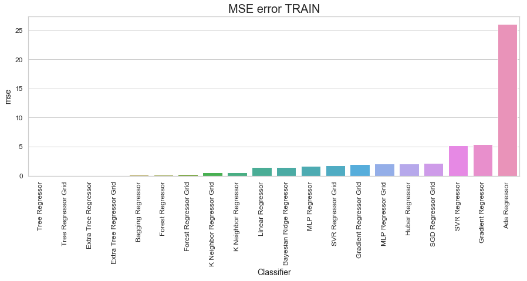

```python
plt.figure(figsize=(15,5))
a = scores_train.sort_values(by = 'mse')
p = sns.barplot(x = a.Classifier, y = a.mse)
p = plt.xticks(rotation=90)
plt.title("MSE error TRAIN", size=20)
# save_fig("MSE error TRAIN")
```

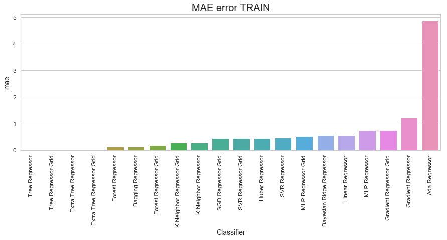

```python
plt.figure(figsize=(15,5))
a = scores_train.sort_values(by = 'mae')
p = sns.barplot(x = a.Classifier, y = a.mae)
p = plt.xticks(rotation=90)
plt.title("MAE error TRAIN", size=20)
# save_fig("MAE error TRAIN")
```

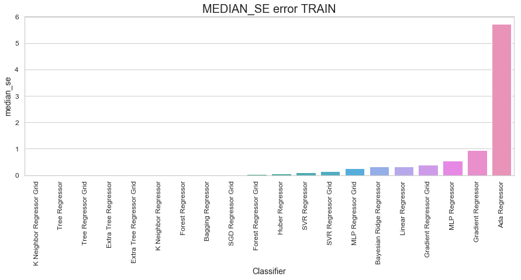

```python
plt.figure(figsize=(15,5))
a = scores_train.sort_values(by = 'median_se')
p = sns.barplot(x = a.Classifier, y = a.median_se)
p = plt.xticks(rotation=90)
plt.title("MEDIAN_SE error TRAIN", size=20)
# save_fig("MEDIAN_SE error TRAIN")
```

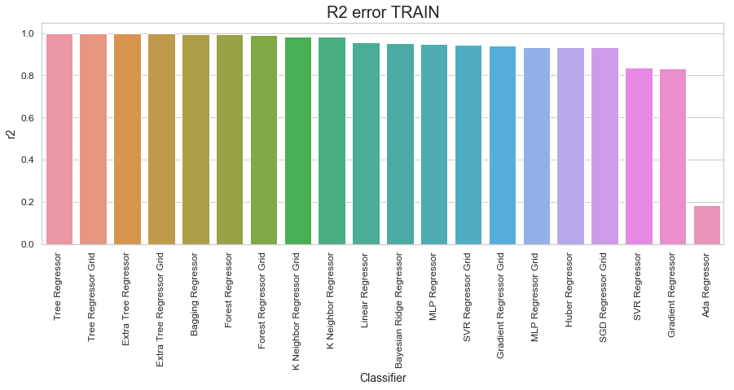

```python
plt.figure(figsize=(15,5))
a = scores_train.sort_values(by = 'r2', ascending = False)
p = sns.barplot(x = a.Classifier, y = a.r2)
p = plt.xticks(rotation=90)
plt.title("R2 error TRAIN", size=20)
# save_fig("R2 error TRAIN")
```

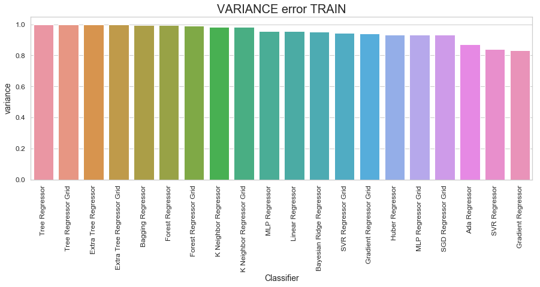

```python
plt.figure(figsize=(15,5))
a = scores_train.sort_values(by = 'variance', ascending = False)
p = sns.barplot(x = a.Classifier, y = a.variance)
p = plt.xticks(rotation=90)
plt.title("VARIANCE error TRAIN", size=20)
# save_fig("VARIANCE error TRAIN")
```

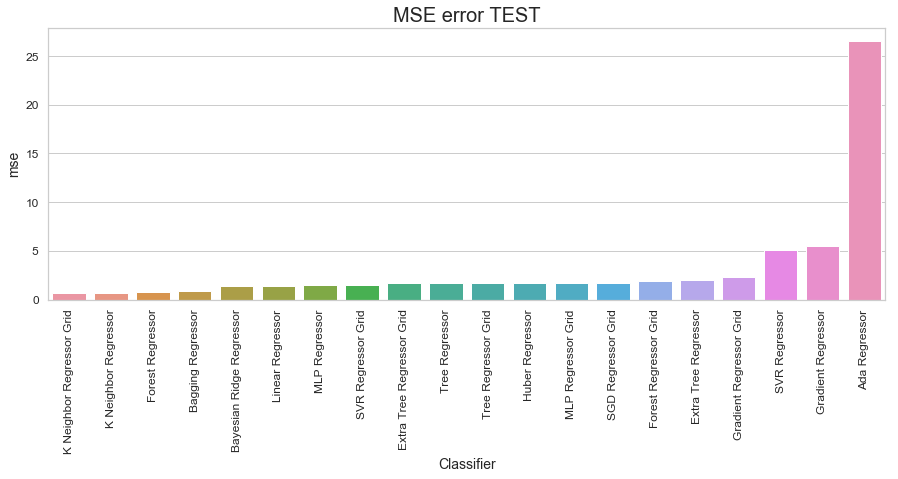

```python
plt.figure(figsize=(15,5))
a = scores_test.sort_values(by = 'mse')
p = sns.barplot(x = a.Classifier, y = a.mse)
p = plt.xticks(rotation=90)
plt.title("MSE error TEST", size=20)
# save_fig("MSE error TEST")
```

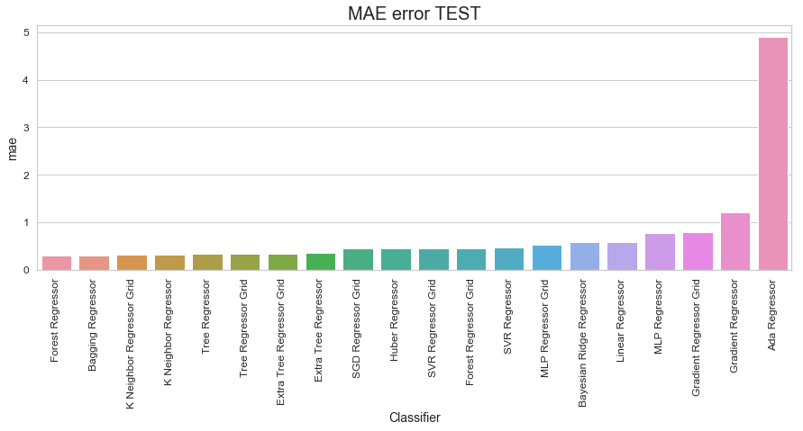

```python
plt.figure(figsize=(15,5))
a = scores_test.sort_values(by = 'mae')
p = sns.barplot(x = a.Classifier, y = a.mae)
p = plt.xticks(rotation=90)
plt.title("MAE error TEST", size=20)
# save_fig("MAE error TEST")
```

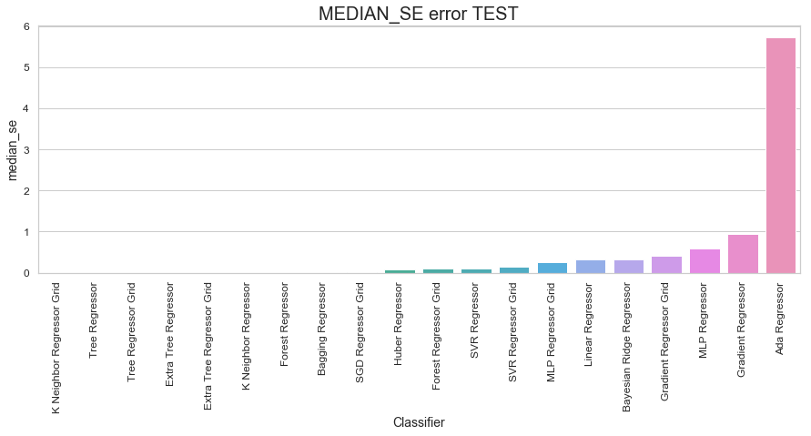

```python
plt.figure(figsize=(15,5))
a = scores_test.sort_values(by = 'median_se')
p = sns.barplot(x = a.Classifier, y = a.median_se)
p = plt.xticks(rotation=90)
plt.title("MEDIAN_SE error TEST", size=20)
# save_fig("MEDIAN_SE error TEST")
```